# TITANIC DATA SET CLASSIFICATION ANALYSIS

IMPORT DATA WRANGLING LIBRARIES

```python
## Import data wrangling libraries
import numpy as np
import pandas as pd
from pandas import read_csv
from pandas.plotting import scatter_matrix
import random as rnd
from numpy.linalg import eig
```

VISUALIZATION LIBRARIES

I have included several visualizations using the Bokeh interactive library. To view these charts and interact with them, it is necessary to run the Jupyter Notebook. However, I have also included static visualizations using libraries such as Seaborn and Matplotlib, which are readily visible without running any code. These visualizations provide a comprehensive overview of the data, allowing for a deeper understanding of the patterns, relationships, and insights derived from the analysis. </font>

```python
## Import visualization libraries
import seaborn as sns
import matplotlib.pyplot as plt
%matplotlib inline
from matplotlib import pyplot
from matplotlib.pyplot import MultipleLocator

## Import interactive Bokeh libraries
from bokeh.io import push_notebook, show, output_notebook
from bokeh.palettes import Category20c
from bokeh.layouts import row
from bokeh.plotting import figure
from bokeh.transform import cumsum
from bokeh.io import show
import pandas_bokeh
from bokeh.io import output_notebook
from bokeh.plotting import figure, show
from bokeh.plotting import figure, output_file, show
from bokeh.models.widgets import DataTable, TableColumn
pandas_bokeh.output_notebook()
from bokeh.plotting import output_file, show
```

IMPORT MACHINE LEARINING MODELS

```python
## import machine learning models
from sklearn.svm import SVC, LinearSVC
from catboost import CatBoostClassifier
from sklearn.linear_model import SGDClassifier
from sklearn.linear_model import LogisticRegression
from sklearn.tree import DecisionTreeClassifier
from sklearn.neighbors import KNeighborsClassifier
from sklearn.discriminant_analysis import LinearDiscriminantAnalysis
from sklearn.naive_bayes import GaussianNB
from sklearn.ensemble import RandomForestClassifier
from sklearn.datasets import make_classification
```

IMPORT PREPROCESSING AND EVALUATION LIBRARIES

```python
# Import evaluation libraries

from sklearn.model_selection import GridSearchCV, cross_val_score
from sklearn.preprocessing import StandardScaler
from sklearn.decomposition import PCA
from sklearn.model_selection import train_test_split
from sklearn.model_selection import cross_val_score
from sklearn.model_selection import StratifiedKFold
from sklearn.metrics import classification_report
from sklearn.metrics import confusion_matrix
from sklearn.metrics import accuracy_score
from sklearn.preprocessing import StandardScaler
from sklearn.decomposition import PCA
from pandas import read_csv
from pandas.plotting import scatter_matrix
import warnings
warnings.filterwarnings("ignore", category=UserWarning)
```

LOADING DATA

```python
## Lodining data into pandas dataframe

df_train = pd.read_csv('data/titanic_train.csv') # titanic training data from kaggle
df_test = pd.read_csv('data/titanic_test.csv') # titanic testing data from kaggle

df_train =df_train.iloc[:,0:len(df_train)] # data retrieval
df_test =df_test.iloc[:,0:len(df_train)] # data retrieval

pd.set_option('display.max_columns', 12) # display 12 columns
pd.set_option('display.max_rows', 10) # display 10 rows
pd.set_option('display.width', 1000) # display 1000 charactors
```

# EXPLORATORY ANALYSIS

```python
df_train.info() # train dataset information
```

```
<class 'pandas.core.frame.DataFrame'>
RangeIndex: 891 entries, 0 to 890
Data columns (total 12 columns):
 #   Column       Non-Null Count  Dtype
---  ------       --------------  -----
 0   PassengerId  891 non-null    int64
 1   Survived     891 non-null    int64
 2   Pclass       891 non-null    int64
 3   Name         891 non-null    object
 4   Sex          891 non-null    object
 5   Age          714 non-null    float64
 6   SibSp        891 non-null    int64
 7   Parch        891 non-null    int64
 8   Ticket       891 non-null    object
 9   Fare         891 non-null    float64
 10  Cabin        204 non-null    object
 11  Embarked     889 non-null    object
dtypes: float64(2), int64(5), object(5)
memory usage: 83.7+ KB
```

```python
df_test.info() # test dataset information
```

```
<class 'pandas.core.frame.DataFrame'>
RangeIndex: 418 entries, 0 to 417
Data columns (total 11 columns):
 #   Column       Non-Null Count  Dtype
---  ------       --------------  -----
 0   PassengerId  418 non-null    int64
 1   Pclass       418 non-null    int64
 2   Name         418 non-null    object
 3   Sex          418 non-null    object
 4   Age          332 non-null    float64
 5   SibSp        418 non-null    int64
 6   Parch        418 non-null    int64
 7   Ticket       418 non-null    object
 8   Fare         417 non-null    float64
 9   Cabin        91 non-null     object
 10  Embarked     418 non-null    object
dtypes: float64(2), int64(4), object(5)
memory usage: 36.0+ KB
```

The test dataset contain 11 columns with 418 rows as shown above. There are 2 float64, 4 int64 and 5 objects data type exists. However, data missing for Age, Fare and Cabin features. Will work on how to manage those missing values in later sections

```python
print('Shape of the train dataset:', df_train.shape) ## get the shape of the train data
#print()
print('Shape of the test dataset:',df_test.shape) ## eet the shape of the test data
```

```
Shape of the train dataset: (891, 12)
Shape of the test dataset: (418, 11)
```

```python
print('Columns of train dataset:',df_train.columns.values) # get column values of train data
print()
print('Columns of test dataset:',df_test.columns.values) # get column values of test data
```

```
Columns of train dataset: ['PassengerId' 'Survived' 'Pclass' 'Name' 'Sex' 'Age' 'SibSp' 'Parch'
 'Ticket' 'Fare' 'Cabin' 'Embarked']

Columns of test dataset: ['PassengerId' 'Pclass' 'Name' 'Sex' 'Age' 'SibSp' 'Parch' 'Ticket' 'Fare'
 'Cabin' 'Embarked']
```

```python
## Checking for duplicate entries with unique PassengerId
duplicate1 = df_train[df_train.duplicated('PassengerId')]
print('Train dataset:',duplicate1)

print()
duplicate2 = df_test[df_test.duplicated('PassengerId')]
print('Test dataset', duplicate2)
```

```
Train dataset: Empty DataFrame
Columns: [PassengerId, Survived, Pclass, Name, Sex, Age, SibSp, Parch, Ticket, Fare, Cabin, Embarked]
Index: []

Test dataset Empty DataFrame
Columns: [PassengerId, Pclass, Name, Sex, Age, SibSp, Parch, Ticket, Fare, Cabin, Embarked]
Index: []
```

There is no duplicate entries in both datasets

```python
df_test.head(5) # get top 5 rows of train dataset
```

|  | PassengerId | Pclass | Name | Sex | Age | SibSp | Parch | Ticket | Fare | Cabin | Embarked |
| --- | --- | --- | --- | --- | --- | --- | --- | --- | --- | --- | --- |
| 0 | 892 | 3 | Kelly, Mr. James | male | 34.5 | 0 | 0 | 330911 | 7.8292 | NaN | Q |
| 1 | 893 | 3 | Wilkes, Mrs. James (Ellen Needs) | female | 47.0 | 1 | 0 | 363272 | 7.0000 | NaN | S |
| 2 | 894 | 2 | Myles, Mr. Thomas Francis | male | 62.0 | 0 | 0 | 240276 | 9.6875 | NaN | Q |
| 3 | 895 | 3 | Wirz, Mr. Albert | male | 27.0 | 0 | 0 | 315154 | 8.6625 | NaN | S |
| 4 | 896 | 3 | Hirvonen, Mrs. Alexander (Helga E Lindqvist) | female | 22.0 | 1 | 1 | 3101298 | 12.2875 | NaN | S |

```python
df_train.tail(5) # get bottom 5 rows of train dataset
```

|  | PassengerId | Survived | Pclass | Name | Sex | Age | SibSp | Parch | Ticket | Fare | Cabin | Embarked |
| --- | --- | --- | --- | --- | --- | --- | --- | --- | --- | --- | --- | --- |
| 886 | 887 | 0 | 2 | Montvila, Rev. Juozas | male | 27.0 | 0 | 0 | 211536 | 13.00 | NaN | S |
| 887 | 888 | 1 | 1 | Graham, Miss. Margaret Edith | female | 19.0 | 0 | 0 | 112053 | 30.00 | B42 | S |
| 888 | 889 | 0 | 3 | Johnston, Miss. Catherine Helen "Carrie" | female | NaN | 1 | 2 | W./C. 6607 | 23.45 | NaN | S |
| 889 | 890 | 1 | 1 | Behr, Mr. Karl Howell | male | 26.0 | 0 | 0 | 111369 | 30.00 | C148 | C |
| 890 | 891 | 0 | 3 | Dooley, Mr. Patrick | male | 32.0 | 0 | 0 | 370376 | 7.75 | NaN | Q |

```python
df_test.head(5) # get top 5 rows of test dataset
```

|  | PassengerId | Pclass | Name | Sex | Age | SibSp | Parch | Ticket | Fare | Cabin | Embarked |
| --- | --- | --- | --- | --- | --- | --- | --- | --- | --- | --- | --- |
| 0 | 892 | 3 | Kelly, Mr. James | male | 34.5 | 0 | 0 | 330911 | 7.8292 | NaN | Q |
| 1 | 893 | 3 | Wilkes, Mrs. James (Ellen Needs) | female | 47.0 | 1 | 0 | 363272 | 7.0000 | NaN | S |
| 2 | 894 | 2 | Myles, Mr. Thomas Francis | male | 62.0 | 0 | 0 | 240276 | 9.6875 | NaN | Q |
| 3 | 895 | 3 | Wirz, Mr. Albert | male | 27.0 | 0 | 0 | 315154 | 8.6625 | NaN | S |
| 4 | 896 | 3 | Hirvonen, Mrs. Alexander (Helga E Lindqvist) | female | 22.0 | 1 | 1 | 3101298 | 12.2875 | NaN | S |

```python
df_test.tail(5) ## get bottom 5 rows of test data
```

|  | PassengerId | Pclass | Name | Sex | Age | SibSp | Parch | Ticket | Fare | Cabin | Embarked |
| --- | --- | --- | --- | --- | --- | --- | --- | --- | --- | --- | --- |
| 413 | 1305 | 3 | Spector, Mr. Woolf | male | NaN | 0 | 0 | A.5. 3236 | 8.0500 | NaN | S |
| 414 | 1306 | 1 | Oliva y Ocana, Dona. Fermina | female | 39.0 | 0 | 0 | PC 17758 | 108.9000 | C105 | C |
| 415 | 1307 | 3 | Saether, Mr. Simon Sivertsen | male | 38.5 | 0 | 0 | SOTON/O.Q. 3101262 | 7.2500 | NaN | S |
| 416 | 1308 | 3 | Ware, Mr. Frederick | male | NaN | 0 | 0 | 359309 | 8.0500 | NaN | S |
| 417 | 1309 | 3 | Peter, Master. Michael J | male | NaN | 1 | 1 | 2668 | 22.3583 | NaN | C |

INSPECTION OF MISSING DATA

```python
## Checking of missing data info in train dataset

total_missing1 = df_train.isnull().sum().sort_values(ascending=False) # sum of total missing values
sub_1 = df_train.isnull().sum()/df_train.isnull().count()*100 # calculate the percetage of missing value
sub_2 = (round(sub_1, 2)).sort_values(ascending=False) # round to 2 decimal and sort values

missing_data = pd.concat([total_missing1, sub_2], axis=1, keys=['Total', '%'])# joined total missing and percentage in dataframe
missing_data.head()
```

|  | Total | % |
| --- | --- | --- |
| Cabin | 687 | 77.10 |
| Age | 177 | 19.87 |
| Embarked | 2 | 0.22 |
| PassengerId | 0 | 0.00 |
| Survived | 0 | 0.00 |

The Cabin feature has 77.1% missing data, followed by the Age feature with 19.87% missing data, and the Embarked feature with 0.22% missing data in the train dataset.

```python
## Checking of missing data info in test dataset

total_missing = df_test.isnull().sum().sort_values(ascending=False)# sum of total missing values
sub_3 = df_test.isnull().sum()/df_test.isnull().count()*100  # calculate the percetage of missing value
sub_4 = (round(sub_3, 2)).sort_values(ascending=False) #round to 2 decimal and sort values

missing_data = pd.concat([total_missing, sub_4], axis=1, keys=['Total', '%'])# joined total missing and percentage in dataframe
missing_data.head()
```

|  | Total | % |
| --- | --- | --- |
| Cabin | 327 | 78.23 |
| Age | 86 | 20.57 |
| Fare | 1 | 0.24 |
| PassengerId | 0 | 0.00 |
| Pclass | 0 | 0.00 |

The Cabin feature has 78.23% missing data, followed by the Age feature with 20.57% missing data, and the Fare feature with 0.24% missing data in the test dataset.

DESCRIPTIVE STATISTICAL ANALYSIS

```python
df_train.describe()# descriptive statistical analysis of train dataset
```

|  | PassengerId | Survived | Pclass | Age | SibSp | Parch | Fare |
| --- | --- | --- | --- | --- | --- | --- | --- |
| count | 891.000000 | 891.000000 | 891.000000 | 714.000000 | 891.000000 | 891.000000 | 891.000000 |
| mean | 446.000000 | 0.383838 | 2.308642 | 29.699118 | 0.523008 | 0.381594 | 32.204208 |
| std | 257.353842 | 0.486592 | 0.836071 | 14.526497 | 1.102743 | 0.806057 | 49.693429 |
| min | 1.000000 | 0.000000 | 1.000000 | 0.420000 | 0.000000 | 0.000000 | 0.000000 |
| 25% | 223.500000 | 0.000000 | 2.000000 | 20.125000 | 0.000000 | 0.000000 | 7.910400 |
| 50% | 446.000000 | 0.000000 | 3.000000 | 28.000000 | 0.000000 | 0.000000 | 14.454200 |
| 75% | 668.500000 | 1.000000 | 3.000000 | 38.000000 | 1.000000 | 0.000000 | 31.000000 |
| max | 891.000000 | 1.000000 | 3.000000 | 80.000000 | 8.000000 | 6.000000 | 512.329200 |

Both the Age and Fare features provide significant information.

The Age feature ranges from 0.42 to 80, with a mean of 29.7 and a standard deviation of 14.5.

Similarly, the Fare feature ranges from 0 to 512.3, with a mean of 32.2 and a standard deviation of 49.7. This suggests that the Fare feature has a wider spread of values compared to the Age feature.

Additionally, the Pclass feature consists of 3 classes of values, while the SibSp feature is distributed between 0 and 8, and the Parch feature ranges from 0 to 6. These features provide varying levels of diversity in their values.

However, the PassengerId and Survived (target) features do not exhibit significant statistical variations and may not provide substantial insights on their own. </font>

```python
df_test.describe() #descriptive statistical analysis of train dataset
```

|  | PassengerId | Pclass | Age | SibSp | Parch | Fare |
| --- | --- | --- | --- | --- | --- | --- |
| count | 418.000000 | 418.000000 | 332.000000 | 418.000000 | 418.000000 | 417.000000 |
| mean | 1100.500000 | 2.265550 | 30.272590 | 0.447368 | 0.392344 | 35.627188 |
| std | 120.810458 | 0.841838 | 14.181209 | 0.896760 | 0.981429 | 55.907576 |
| min | 892.000000 | 1.000000 | 0.170000 | 0.000000 | 0.000000 | 0.000000 |
| 25% | 996.250000 | 1.000000 | 21.000000 | 0.000000 | 0.000000 | 7.895800 |
| 50% | 1100.500000 | 3.000000 | 27.000000 | 0.000000 | 0.000000 | 14.454200 |
| 75% | 1204.750000 | 3.000000 | 39.000000 | 1.000000 | 0.000000 | 31.500000 |
| max | 1309.000000 | 3.000000 | 76.000000 | 8.000000 | 9.000000 | 512.329200 |

Like train dataset,both the Age and Fare features provide significant information.

This suggests that the Fare feature has a wider spread of values compared to the Age feature. When comparing to the train dataset, the Fare featur data is more spread in terms of both mean and standard deviation.

The rest of features are the same nature as train dataset. </font>

```python
df_train.describe(include=['O'])# descriptive statistics of categorical data (object data type) for train dataset
```

|  | Name | Sex | Ticket | Cabin | Embarked |
| --- | --- | --- | --- | --- | --- |
| count | 891 | 891 | 891 | 204 | 889 |
| unique | 891 | 2 | 681 | 147 | 3 |
| top | Braund, Mr. Owen Harris | male | 347082 | B96 B98 | S |
| freq | 1 | 577 | 7 | 4 | 644 |

The 'Name' feature consists of 891 unique values with no missing values, indicating that each passenger has a distinct name.The top value is 'Braund, Mr. Owen Harris', which occurs only once in the dataset.

The 'Sex' feature has 2 distinct values, suggesting that passengers are categorized as either male or female.The most frequent value is 'male', which occurs 577 times.

The 'Ticket' feature has 681 unique values indicating a variety of ticket numbers.The most frequent ticket value is '347082', which appears 7 times.

The 'Cabin' feature has 147 unique values, suggesting that multiple passengers may share the same cabin. The top value is 'B96 B98', occurring 4 times in the dataset.

The 'Embarked' feature has 3 unique values, 'S', 'C', and 'Q', representing the ports where passengers embarked. The most frequent value is 'S', which appears 644 times. </font>

```python
df_test.describe(include=['O'])# descriptive statistics of categorical data (object data type)for test dataset
```

|  | Name | Sex | Ticket | Cabin | Embarked |
| --- | --- | --- | --- | --- | --- |
| count | 418 | 418 | 418 | 91 | 418 |
| unique | 418 | 2 | 363 | 76 | 3 |
| top | Kelly, Mr. James | male | PC 17608 | B57 B59 B63 B66 | S |
| freq | 1 | 266 | 5 | 3 | 270 |

The 'Name' feature consists of 418 unique values, indicating that each passenger has a distinct name.The top value is 'Kelly, Mr. James', which occurs only once in the dataset.

The 'Sex' feature has 2 distinct values same as train dataset.The most frequent value is 'male', which occurs 266 times. The 'Ticket' feature has 363 unique values where the most frequent ticket value is 'PC 17608', which appears 5 times.

The 'Cabin' feature has 76 unique values, suggesting that multiple passengers may share the same cabin.The top value is 'B57 B59 B63 B66', occurring 3 times in the dataset.

CORRELATION ANALYSIS

```python
cormat = df_train.corr().round(2)  # correlation matrix of the train dataset
cormat
```

|  | PassengerId | Survived | Pclass | Age | SibSp | Parch | Fare |
| --- | --- | --- | --- | --- | --- | --- | --- |
| PassengerId | 1.00 | -0.01 | -0.04 | 0.04 | -0.06 | -0.00 | 0.01 |
| Survived | -0.01 | 1.00 | -0.34 | -0.08 | -0.04 | 0.08 | 0.26 |
| Pclass | -0.04 | -0.34 | 1.00 | -0.37 | 0.08 | 0.02 | -0.55 |
| Age | 0.04 | -0.08 | -0.37 | 1.00 | -0.31 | -0.19 | 0.10 |
| SibSp | -0.06 | -0.04 | 0.08 | -0.31 | 1.00 | 0.41 | 0.16 |
| Parch | -0.00 | 0.08 | 0.02 | -0.19 | 0.41 | 1.00 | 0.22 |
| Fare | 0.01 | 0.26 | -0.55 | 0.10 | 0.16 | 0.22 | 1.00 |

```python
cormat = df_test.corr().round(2)  # correlation matrix of the test dataset
cormat
```

|  | PassengerId | Pclass | Age | SibSp | Parch | Fare |
| --- | --- | --- | --- | --- | --- | --- |
| PassengerId | 1.00 | -0.03 | -0.03 | 0.00 | 0.04 | 0.01 |
| Pclass | -0.03 | 1.00 | -0.49 | 0.00 | 0.02 | -0.58 |
| Age | -0.03 | -0.49 | 1.00 | -0.09 | -0.06 | 0.34 |
| SibSp | 0.00 | 0.00 | -0.09 | 1.00 | 0.31 | 0.17 |
| Parch | 0.04 | 0.02 | -0.06 | 0.31 | 1.00 | 0.23 |
| Fare | 0.01 | -0.58 | 0.34 | 0.17 | 0.23 | 1.00 |

# DATA VISUALIZATION

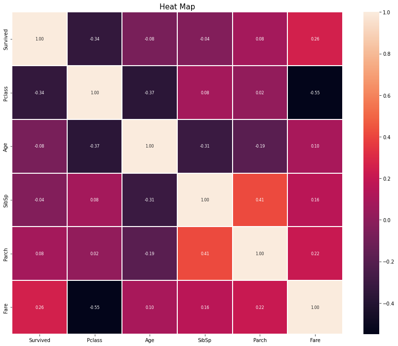

```python
## Correlation matrix and heatmap of train dataset
df0 = df_train.drop(['PassengerId'],
                     #'Survived'],
                    axis=1) # drop the insignificant features
plt.figure(figsize=(15, 12))
sns.heatmap(df0.corr(method = 'pearson'),
            annot = True, fmt = '.2f', linewidths = 0.1,
            linecolor= 'white',
           annot_kws={'size':8})
plt.title('Heat Map', fontsize = 15)
plt.show()
```

TRAIN DATASET

As depicted in the correlation matrix above, this visual representation provide a comprehensive view of the relationships between the predictor variables in the dataset.

An interesting observation is that the variables related to parents and siblings tend to have positive correlations. This finding indicates a tendency for families to travel together.

The Age variable has a higher negative correlation with the number of siblings. This implies that as the number of siblings increases, the age tends to be lower. This correlation could indicate that larger families with more siblings tend to consist of younger individuals.

The Parch and SibSp has a positive correlation indicate they are providing same information in predicting Survived

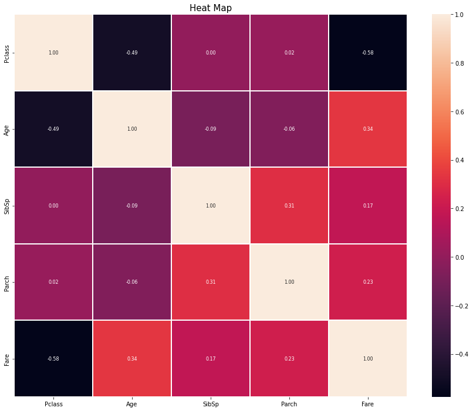

```python
## Correlation matrix and heatmap of test dataset
df1 = df_test.drop(['PassengerId'],axis=1) # drop the insignificant features
plt.figure(figsize=(15, 12))
sns.heatmap(df1.corr(method = 'pearson'),
            annot = True, fmt = '.2f', linewidths = 0.1,
            linecolor= 'white',
           annot_kws={'size':8})
plt.title('Heat Map', fontsize = 15)
plt.show()
```

TEST DATASET

Age vs. Pclass (-0.49): There is a moderate negative correlation between 'Age' and 'Pclass'. This indicates that as the passenger class decreases (moving from higher class to lower class), the average age of the passengers tends to be younger.

Age vs. Fare (0.34): There is a moderate positive correlation between 'Age' and 'Fare'. This suggests that as the age of passengers increases, the fare tends to be higher.

SibSp vs. Parch (0.31): There is a moderate positive correlation between 'SibSp' (number of siblings/spouses aboard) and 'Parch' (number of parents/children aboard). This implies that passengers who had more siblings/spouses were also more likely to have more parents/children on board.

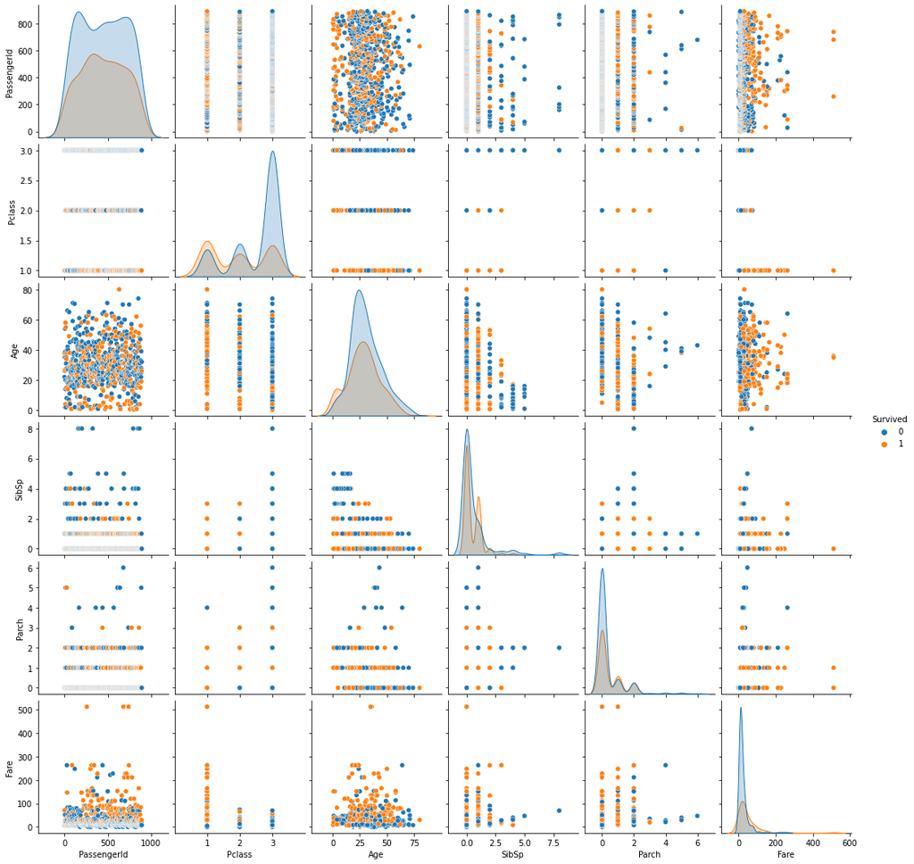

```python
## Pairwise relationship between features in train dataset
sns.pairplot(df_train, hue='Survived', height = 2.5)
```

The trend and pattern shows a positive correlation and suggests that as age increases, the fare tends to be higher, indicating that older passengers might have purchased more expensive tickets.

The cluster of survived passengers exhibits a wide age range of approximately 18-45, accompanied by a dispersed range of fare values. This observation suggests a potential correlation between these passengers and a higher likelihood of survival

The pair plot reveals a distinct relationship between survival and passenger class. It is evident that a greater proportion of passengers in class 1 survived, in comparison to those in class 2 and 3.

It seems a smaller family size is associated with a higher chance of survival. Conversely, the chances of survival decrease notably when the family size exceeds three.

The smaller number of siblings and spouses is positively correlated with a higher chance of survival. In addition,it is noticeable that passengers who had parents or children, along with siblings or spouses, tended to travel together. This observation suggests a relationship between these variables and their impact on survival rates.

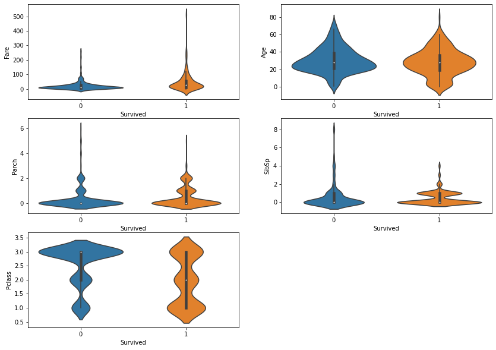

```python
## Plotting the distributions of numrical features
plt.figure(figsize=(14, 10))
plt.subplot(321)
sns.violinplot(x = "Survived", y = "Fare", data=df_train, size =10)
plt.subplot(322)
sns.violinplot(x = "Survived", y = "Age", data=df_train, size = 10)
plt.subplot(323)
sns.violinplot(x = "Survived", y = "Parch", data=df_train, size = 10)
plt.subplot(324)
sns.violinplot(x = "Survived", y = "SibSp", data=df_train, size = 10)
plt.subplot(325)
sns.violinplot(x = "Survived", y = "Pclass", data=df_train, size = 10)
#plt.tight_layout()
plt.show()
```

When comparing the Fare feature with the Survived variable, it can be observed that the majority of passengers with lower fares did not survive. However, a significant number of survivors are from the fare range of 10 to 60.

Regarding the Age feature in relation to survival, it appears that the age distribution is similar for both survived and not survived passengers. The highest density of survivors and non-survivors falls within the age group of approximately 20 to 40, although the density is slightly higher for non-survivors.

In terms of passenger class (Pclass), the majority of non-survivors belong to Pclass 3, followed by Pclass 2 and Pclass 1. On the other hand, the majority of survivors come from Pclass 1 and Pclass 3, while Pclass 2 has a lower representation among survivors.

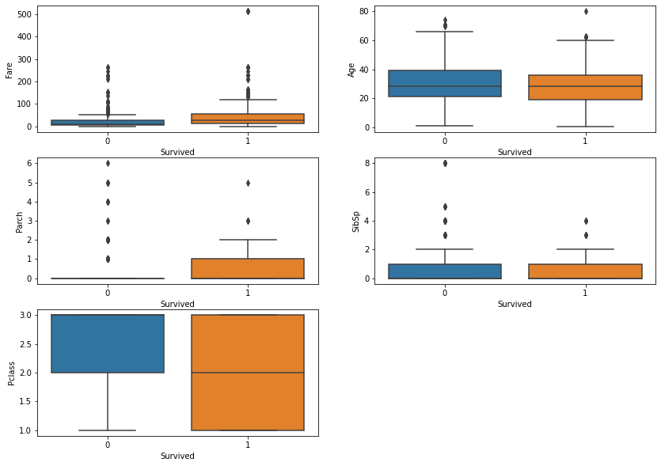

```python
## Plotting the distributions of numrical features
plt.figure(figsize=(14, 10))
plt.subplot(321)
sns.boxplot(x = "Survived", y = "Fare", data=df_train)
plt.subplot(322)
sns.boxplot(x = "Survived", y = "Age", data=df_train)
plt.subplot(323)
sns.boxplot(x = "Survived", y = "Parch", data=df_train)
plt.subplot(324)
sns.boxplot(x = "Survived", y = "SibSp", data=df_train)
plt.subplot(325)
sns.boxplot(x = "Survived", y = "Pclass", data=df_train)
#plt.subplot(326)
#sns.boxplot(x = "Survived", y = "PassengerId", data=df_train)
#plt.tight_layout()
plt.show()
```

In terms of the Fare feature, the median fare is slightly higher for the passengers who survived compared to those who did not survive.

When looking at the Age feature, the median appears to be similar for both survived and not survived passengers. The spread of data between the two groups also appears to be relatively similar.

Regarding the Parch feature, the spread of not survived passengers is concentrated around zero (indicating a smaller family size), while the spread for survived passengers is wider, indicating a broader range of family sizes.

For the SibSp (siblings and spouse) feature, the spread and median values appear to be similar for both survived and not survived passengers.

In relation to the Pclass feature, the spread of data is wider for the survived passengers compared to the not survived passengers. This indicates that there is a greater variation in passenger class among those who survived. However, it's worth noting that there is some overlap in the median values between the survived and not survived groups

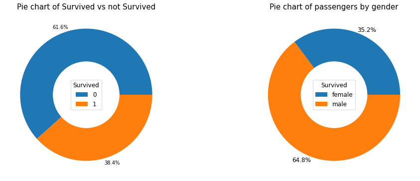

```python
## Pie chart of passengers survived and survived by gender
## subplot 1
plt.figure(figsize=(14, 10))
plt.subplot(221)
pie_t = df_train.groupby(['Survived'])['Survived'].count()# extract pie chart data for 'Survived' feature

labels = list(set(df_train['Survived']))# extract labels
labels.sort()
plt.pie(pie_t, autopct='%1.1f%%',pctdistance=1.1) # data labelformat and location spacing
central_circle = plt.Circle((0, 0), 0.5, color='white') # center hole sizing and color
fig = plt.gcf()
fig.gca().add_artist(central_circle)
plt.rc('font', size=12)
plt.title("Pie chart of Survived vs not Survived", fontsize=15)
plt.legend(labels, loc="center", title="Survived") # legend location and name

## subplot 2
plt.subplot(222)
pie_g = df_train.groupby(['Sex'])['Survived'].count() # extract pie chart data for 'Survived' by gender
plt.pie(pie_g, autopct='%1.1f%%',pctdistance=1.1) # data labelformat and location spacing
central_circle = plt.Circle((0, 0), 0.5, color='white') # center hole sizing and color
fig = plt.gcf()
fig.gca().add_artist(central_circle)
plt.rc('font', size=12)
plt.title("Pie chart of passengers by gender", fontsize=15)

labels = list(set(df_train['Sex'])) # extract labels
plt.legend(labels, loc="center",title="Survived") # legend location and name
labels.sort()

plt.tight_layout()
plt.show()
```

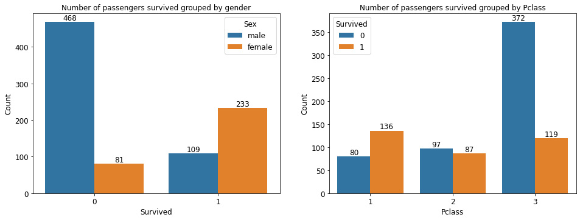

```python
plt.figure(figsize=(16, 12))

## subplot 1 - number of passengers survived by gender
plt.subplot(221)
Survived = sorted(df_train.Survived.unique().tolist())  # Get unique values of 'Survived' and convert to list
ax = sns.countplot(x='Survived', data=df_train, hue='Sex', order=Survived)  # Plot the count of survivors grouped by gender

for i in ax.containers:
    ax.bar_label(i)  # Add labels to the bars

plt.title('Number of passengers survived grouped by gender', fontsize=12)
plt.xlabel('Survived', fontsize=12)
plt.ylabel('Count', fontsize=12)

## subplot 2 - number of passengers survived by Pclass
plt.subplot(222)
Survived = sorted(df_train.Pclass.unique().tolist())  # Get unique values of 'Pclass' and convert to list
ax = sns.countplot(x='Pclass', data=df_train, hue='Survived', order=Survived)  # Plot the count of survivors grouped by Pclass

for t in ax.containers:
    ax.bar_label(t)  # Add labels to the bars

plt.title('Number of passengers survived grouped by Pclass', fontsize=12)
plt.xlabel('Pclass', fontsize=12)
plt.ylabel('Count', fontsize=12)

plt.show()
```

The number of passengers who did not survive includes 468 males and 81 females, while the number of survivors includes 233 females and 109 males.

The number of passengers who survived in Pclass 1 is 136, in Pclass 2 is 87, and in Pclass 3 is 119. The number of passengers who did not survive in Pclass 1 is 80, in Pclass 2 is 97, and in Pclass 3 is 372.

```python
## Number of passengers survived in each Pclass category
plt_p = df_train.groupby(['Pclass', 'Survived'])['Survived'].count().unstack()

plt_p.plot_bokeh(kind="bar", title="Number of passengers survived in each Pclass category",
                 figsize=(800, 500),
                 xlabel="Pclass",
                 ylabel="Count",
                 stacked=True)

plt_p
```

[interactive chart not shown]

| Survived Pclass | 0 | 1 |
| --- | --- | --- |
| 1 | 80 | 136 |
| 2 | 97 | 87 |
| 3 | 372 | 119 |

Creates a stacked bar plot using the Bokeh library

```python
## Number of passengers survived in each Parch category
plt_p = df_train.groupby(['Parch', 'Survived'])['Survived'].count().unstack()

plt_p.plot_bokeh(kind="line", title="Number of passengers Survived by Parch category",
                 figsize=(800, 500),
                 xlabel="Parch category",
                 ylabel="Count",)
                 #stacked=False)

plt_p
```

[interactive chart not shown]

| Survived Parch | 0 | 1 |
| --- | --- | --- |
| 0 | 445.0 | 233.0 |
| 1 | 53.0 | 65.0 |
| 2 | 40.0 | 40.0 |
| 3 | 2.0 | 3.0 |
| 4 | 4.0 | NaN |
| 5 | 4.0 | 1.0 |
| 6 | 1.0 | NaN |

```python
## Number of passengers survived in each SibSP category
plt_sp = df_train.groupby(['SibSp', 'Survived'])['Survived'].count().unstack()

plt_sp.plot_bokeh(kind="line", title="Number of passengers Survived by SibSp category",
                 figsize=(800, 500),
                 xlabel="SibSp category",
                 ylabel="Count",)
                 #stacked=False)

plt_sp
```

[interactive chart not shown]

| Survived SibSp | 0 | 1 |
| --- | --- | --- |
| 0 | 398.0 | 210.0 |
| 1 | 97.0 | 112.0 |
| 2 | 15.0 | 13.0 |
| 3 | 12.0 | 4.0 |
| 4 | 15.0 | 3.0 |
| 5 | 5.0 | NaN |
| 8 | 7.0 | NaN |

Creates a line chart using the Bokeh library.

A significant number of passengers who both survived and did not survive belonged to the small Parch category. As the number of Parch category increases, the chances of survival decreases. However, it is noted that the rate of non-survival also decreases with higher Parch categories.

```python
## number of passengers survuved in pclass group by gender

bar_p = df_train.groupby(['Embarked','Survived'])['Survived'].count().unstack()

bar_p.plot_bokeh(kind="bar",title ="Number of passengers Survived in each deck ",
                   figsize =(800,500),
                   xlabel = "Embarked",
                   ylabel="Count",stacked= False,legend = True)

bar_p
```

[interactive chart not shown]

| Survived Embarked | 0 | 1 |
| --- | --- | --- |
| C | 75 | 93 |
| Q | 47 | 30 |
| S | 427 | 217 |

Creates a bar chart using the Bokeh library.

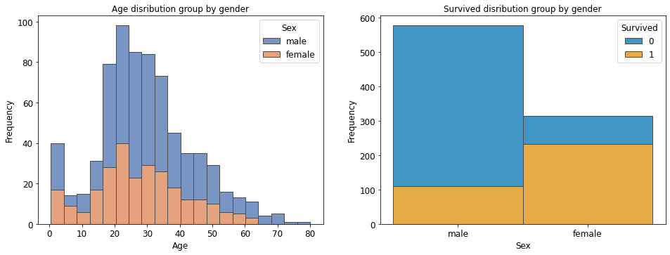

```python
## Distributions

plt.figure(figsize=(16, 12))
## Subplot of passengers Age group by Gender
plt.subplot(221)
sns.histplot(df_train, x= "Age", hue="Sex",
             multiple="stack", palette="deep",
             edgecolor=".3", linewidth=1)

plt.title('Age disribution group by gender', fontsize = 12)
plt.xlabel('Age', fontsize = 12)
plt.ylabel('Frequency', fontsize = 12)

## Subplot of passengers Survived group by Gender
plt.subplot(222)
sns.histplot(df_train, x= "Sex", hue="Survived",
             multiple="stack", palette="colorblind",
             edgecolor=".3", linewidth=1)

plt.title('Survived disribution group by gender', fontsize = 12)
plt.xlabel('Sex', fontsize = 12)
plt.ylabel('Frequency', fontsize = 12)

plt.show()
```

The age distributions of both males and females in the dataset appear to be right-skewed. The majority of males fall within the age range of 15-50, with a higher number of male infants and children compared to females. Additionally, there is a noticeable presence of older-aged males. The age distribution for females is more concentrated in the range of 15-40.

As expected, the survival distribution is more skewed towards females compared to males. This means a higher proportion of females survived as compared to males.

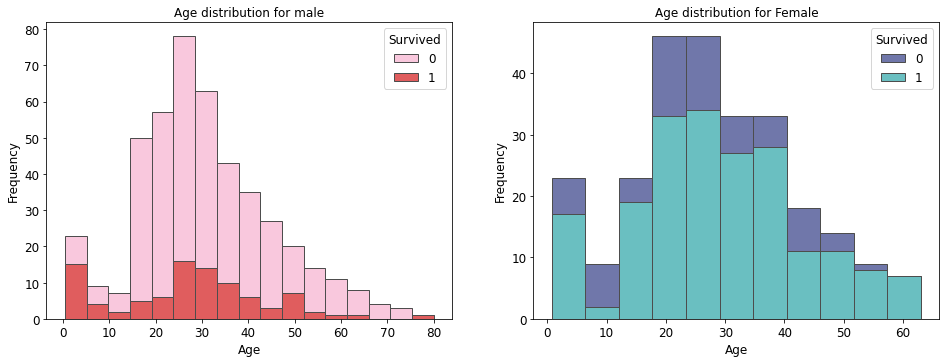

```python
## Survival disrtibition by Age and gender

plt.figure(figsize=(16, 12))
## Subplot of passengers' Age distribution for males
plt.subplot(221)
sns.histplot(df_train[df_train['Sex']=='male'], x="Age", hue="Survived",
             multiple="stack", palette="tab20_r",
             edgecolor=".3", linewidth=1)

plt.title('Age distribution for male', fontsize=12)
plt.xlabel('Age', fontsize=12)
plt.ylabel('Frequency', fontsize=12)

## Subplot of passengers' Age distribution for females
plt.subplot(222)
sns.histplot(df_train[df_train['Sex']=='female'], x="Age", hue="Survived",
             multiple="stack", palette="mako",
             edgecolor=".3", linewidth=1)

plt.title('Age distribution for Female', fontsize=12)
plt.xlabel('Age', fontsize=12)
plt.ylabel('Frequency', fontsize=12)

plt.show()
```

Also, men have a notably lower probability of survival between the ages of 5 and 18, as well as after the age of 35. However, this trend is not observed for women.

Furthermore, it is worth noting that infants have a higher probability of survival, regardless of gender.

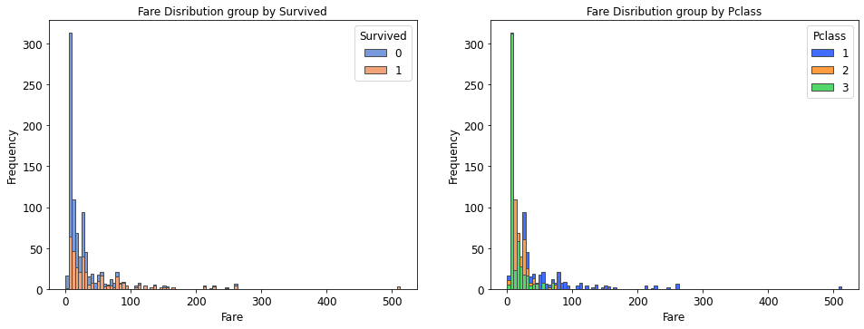

```python
plt.figure(figsize=(16, 12))

## Fare distribution group by Sirvived
plt.subplot(221)
sns.histplot(df_train, x= "Fare", hue="Survived",
             multiple="stack", palette="muted",
             edgecolor=".3", linewidth=1)
plt.title('Fare Disribution group by Survived', fontsize = 12)
plt.xlabel('Fare', fontsize = 12)
plt.ylabel('Frequency', fontsize = 12)

## Fare distribution group by Pclass
plt.subplot(222)
sns.histplot(df_train, x= "Fare", hue="Pclass",
             multiple="stack", palette="bright",
             edgecolor=".3", linewidth=1)
plt.title('Fare Disribution group by Pclass', fontsize = 12)
plt.xlabel('Fare', fontsize = 12)
plt.ylabel('Frequency', fontsize = 12)
plt.show()
```

The Fare distribution appears to be right-skewed, with a majority of survivors and non-survivors falling within the lower fare range. However,there are some extreme fare values observed among those who survived.

As anticipated, passengers in Class 3 have lower fare values, followed by those in Class 2 and Class 1. This aligns with the expectations that lower-class passengers generally paid lower fares.

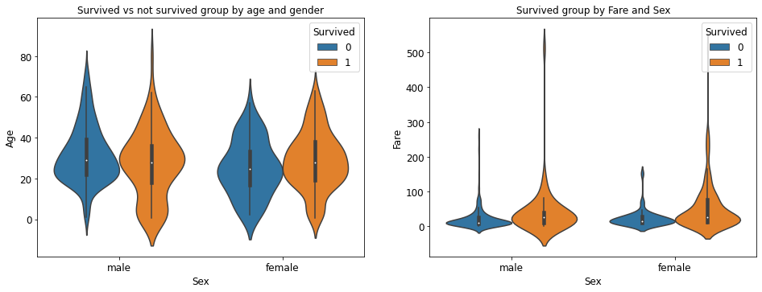

```python
plt.figure(figsize=(16, 12))

## Violin plot distribution of passengers Survived group by Gender and Age
plt.subplot(221)
female = df_train[df_train['Sex']=='female'] # extract female gender details
male = df_train[df_train['Sex']=='male'] # extraxt male gender details
age = df_train.Age
sex = df_train.Sex
survived = df_train.Survived
sns.violinplot(x= sex, y=age,hue = survived,
               scale = 'width',alpha= 0.7)
plt.title("Survived vs not survived group by age and gender", fontsize = 12)
plt.ylabel("Age",fontsize = 12)
plt.xlabel("Sex",fontsize = 12)
plt.xticks(rotation='0')

## Violin plot distribution of passengers Survived group by Gender and Fare
plt.subplot(222)
female = df_train[df_train['Sex']=='female'] # extract female gender details
male = df_train[df_train['Sex']=='male'] # extraxt male gender details
fare = df_train.Fare
sex = df_train.Sex
survived = df_train.Survived
sns.violinplot(x= sex, y=fare,hue = survived,
               scale = 'width',alpha= 0.7)
plt.title("Survived group by Fare and Sex", fontsize = 12)
plt.ylabel("Fare",fontsize = 12)
plt.xlabel("Sex",fontsize = 12)
plt.xticks(rotation='0')
plt.show()
```

The violin chart distribution effectively highlights the survival chances of different age groups based on gender. It is evident that infants and children had a significantly higher survival rate, as well as individuals between the ages of 18 and 40, in both the male and female groups.

As anticipated, the lower fare group has the highest number of survivors in both the male and female groups.

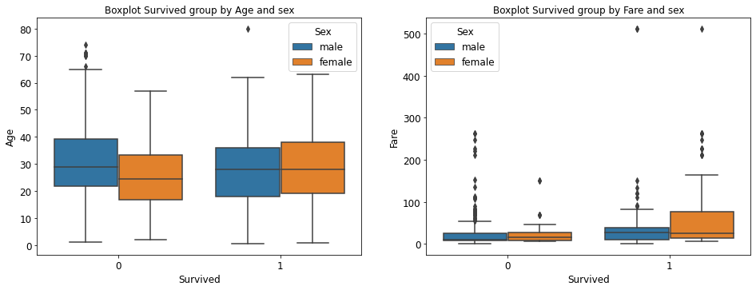

```python
## Boxplot of Fare and age group by gender

plt.figure(figsize=(16, 12))
plt.subplot(221)
sns.boxplot(x="Survived",y="Age",hue = 'Sex',data=df_train)

plt.ylabel("Age", size=12)
plt.xlabel("Survived", size=12)
plt.title("Boxplot Survived group by Age and sex", size=12)

plt.subplot(222)
sns.boxplot(x="Survived",y="Fare",hue = 'Sex',data=df_train)

plt.ylabel("Fare", size=12)
plt.xlabel("Survived", size=12)
plt.title("Boxplot Survived group by Fare and sex", size=12)

plt.show()
```

The box plot of age and sex, grouped by survival, reveals that the median age of female survivors is similar to that of male survivors. However, among the passengers who did not survive, the male group has a higher median age compared to the female group.

In terms of fare, the median fares for passengers who did not survive are similar for both males and females. This trend holds true for the survivors as well. However, the distribution of fares for female survivors is highly right-skewed, indicating that there are some female survivors who paid significantly higher fares compared to the majority of survivors. </font>

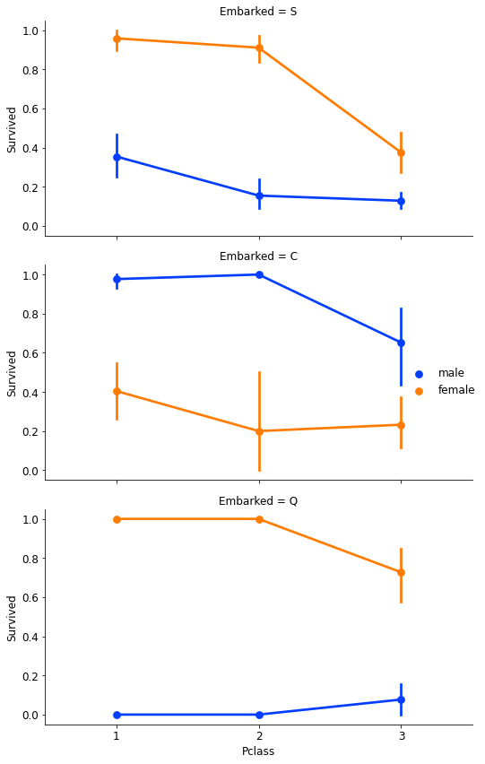

```python
## Check the relashioship between Embarked, Pclass and Sex features
Grid = sns.FacetGrid(df_train, row='Embarked', size= 4, aspect= 1.6)
Grid.map(sns.pointplot, 'Pclass', 'Survived','Sex', palette='bright')
Grid.add_legend()
plt.tight_layout()
plt.show()
```

For the embarkation point 'S'and 'Q', female passengers had higher survival chances in all passenger classes, with the highest chance in Pclass 1. But, for Male passengers had relatively low survival chances across all passenger classes, with the lowest chance in Pclass 3 for embarkation point 'S'. Also, the lowest in embarkation point 'Q' in both Pclass 1 and pclass 2 but slight chance in pclass 3 for Males.

MANAGE OUTLIERS (NOT SUFFICIENT DATA )

```python
## detecting outliers on upper and lower quantiles using the functions

#def quantile_up(df_train_1):

    #Q1 = df_train_1.quantile(0.25) #1st quantile - 25%
    #Q3 = df_train_1.quantile(0.75) #3rd quantile - 75%
    #IQR = Q3 - Q1 #Interquantile range - IQR
    #outlier_step = 1.5 * IQR
    #upper_whisker = df_train_1[df_train_1<=Q3+1.5*IQR].max()
    #return (upper_whisker)

#def quantile_down(df_train_2):

   # Q1 = df_train_2.quantile(0.25) #1st quantile - 25%
    #Q3 = df_train_2.quantile(0.75) #3rd quantile - 75%
    #IQR = Q3 - Q1 #Interquantile range - IQR
    #outlier_step = 1.5 * IQR
    #lower_whisker = df_train_2[df_train_2>=Q1-1.5*IQR].min()
    #return (lower_whisker)
```

```python
## Ploting the remaining data after removing the outliers

#dfr = df_train.copy()
#Q1 = dfr.quantile(0.25)#1st quantile - 25%
#Q3 = dfr.quantile(0.75)#3rd quantile - 75%
#IQR = Q3 - Q1 #Interquantile range - IQR
#df_rem = dfr[~((dfr < (Q1 - 1.5 * IQR)) | \
               #(dfr> (Q3 + 1.5 * IQR))).any(axis=1)]

#print('Remaining data:',df_rem.shape)
#df_rem.info()
```

```python
## detecting outliers on upper and lower quantiles using the functions

#def quantile_up(df_test_1):

    #Q1 = df_test_1.quantile(0.25) #1st quantile - 25%
    #Q3 = df_test_1.quantile(0.75) #3rd quantile - 75%
    #IQR = Q3 - Q1 #Interquantile range - IQR
   # outlier_step = 1.5 * IQR
   # upper_whisker = df_test_1[df_train_1<=Q3+1.5*IQR].max()
   # return (upper_whisker)

#def quantile_down(df_train_2):

    #Q1 = df_test_2.quantile(0.25) #1st quantile - 25%
    #Q3 = df_test_2.quantile(0.75) #3rd quantile - 75%
    #IQR = Q3 - Q1 #Interquantile range - IQR
    #outlier_step = 1.5 * IQR
    #lower_whisker = df_test_2[df_train_2>=Q1-1.5*IQR].min()
   # return (lower_whisker)
```

```python
## Ploting the remaining data after removing the outliers

#dft = df_test.copy()
#Q1 = dft.quantile(0.25)#1st quantile - 25%
#Q3 = dft.quantile(0.75)#3rd quantile - 75%
#IQR = Q3 - Q1 #Interquantile range - IQR
#df_rem_t = dft[~((dft < (Q1 - 1.5 * IQR)) | \
               #(dft> (Q3 + 1.5 * IQR))).any(axis=1)]

#print('Remaining data:',df_rem_t.shape)
#df_rem_t.info()
```

```python
#df_train= df_rem
#df_test=df_rem_t
```

FEATURE ENGINEERING

```python
## Create new feature by looping over both data set and generate a count plot
#mydata = [df_train, df_test]
#for group in mydata:
    #group ['Ticket_Frequency'] = group.groupby('Ticket')['Ticket'].transform('count') # create new feature

#plt.figure(figsize=(10, 8))
#sns.countplot(data=df_train, x='Ticket_Frequency', hue='Survived')
#plt.show()
```

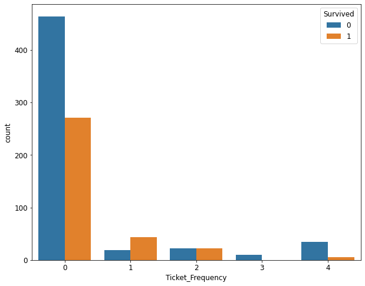

```python
mydata = [df_train, df_test]

for group in mydata:
    group['Ticket_Frequency'] = group.groupby('Ticket')['Ticket'].transform('count')
    group['Ticket_Frequency'] = pd.cut(group['Ticket_Frequency'], bins=5, labels=False)

plt.figure(figsize=(10, 8))
sns.countplot(data=df_train, x='Ticket_Frequency', hue='Survived')
plt.show()
```

Creates a new feature 'Ticket_Frequency' by counting the occurrences of each unique ticket number in both the training dataset (df_train) and the test dataset (df_test). This is aims to capture the frequency of each ticket, which could potentially provide insights into the survival outcome.

```python
## Drop Ticket since new features derived from iT.
mydata = [df_train,df_test]
for group in mydata:
    group.drop([ 'Ticket'], axis = 1,inplace = True)
```

```python
## Set Survived feature as target variable for analysis
target = df_train['Survived']
target.head()
```

```
0    0
1    1
2    1
3    1
4    0
Name: Survived, dtype: int64
```

```python
## creating new feature by cobmining both Parch and SbSp

data = [df_train, df_test]
for dataset in data:
    dataset['relatives'] = dataset['SibSp'] + dataset['Parch']
    dataset.loc[dataset['relatives'] > 0, 'alone'] = 'No'
    dataset.loc[dataset['relatives'] == 0, 'alone'] = 'Yes'
    #dataset.drop(['SibSp', 'Parch'],axis = 1,inplace = True)
```

SibSp and Parch would make more sense as a combined feature that shows the total number of relatives a person has on the dataset. So will create the new feature 'relatives' below, and also a value that shows if someone is alone.

By combining 'SibSp' and 'Parch' into the 'Relatives' feature and introducing the 'alone' feature, we can gain insights into the passenger's family size and determine if they are traveling alone or with family.

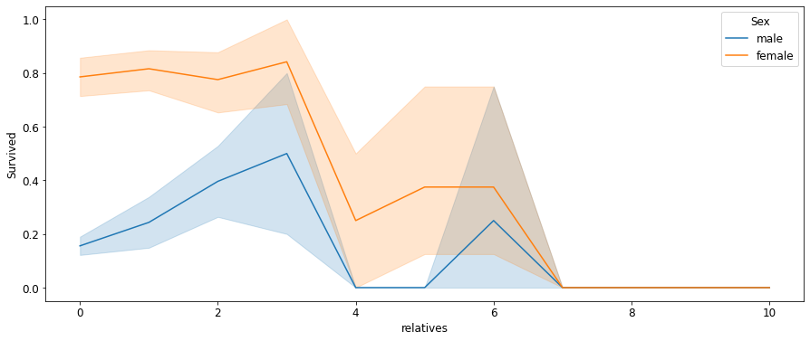

```python
## Create a line chart of relatives travelling together group by gender
plt.figure(figsize=(15,6))
sns.lineplot(data = df_train, x = 'relatives', y = 'Survived',hue = 'Sex')
plt.show()
```

```python
## Explore family member group with gender
df1= df_train.groupby(['relatives','Sex'])['Sex'].count().unstack()
df1
```

| Sex relatives | female | male |
| --- | --- | --- |
| 0 | 126 | 411 |
| 1 | 87 | 74 |
| 2 | 49 | 53 |
| 3 | 19 | 10 |
| 4 | 12 | 3 |
| 5 | 8 | 14 |
| 6 | 8 | 4 |
| 7 | 2 | 4 |
| 10 | 3 | 4 |

The survival chance for female passengers with a group size of up to 3 relatives is higher, but it decreases to 0 when the group size exceeds 6.

On the other hand, for male passengers, the chance of survival increases when traveling with up to 3 relatives, but it drops when the group size reaches 4-5. However, the survival chance increases again when the group size reaches 6, only to drop further when the size exceeds 7.

This suggests that for female passengers, having a small group of relatives increases the chances of survival, but for male passengers, the relationship between group size and survival chance is more complex

```python
## Explore Cabin feature details
df_train['Cabin'].unique()
```

```
array([nan, 'C85', 'C123', 'E46', 'G6', 'C103', 'D56', 'A6',
       'C23 C25 C27', 'B78', 'D33', 'B30', 'C52', 'B28', 'C83', 'F33',
       'F G73', 'E31', 'A5', 'D10 D12', 'D26', 'C110', 'B58 B60', 'E101',
       'F E69', 'D47', 'B86', 'F2', 'C2', 'E33', 'B19', 'A7', 'C49', 'F4',
       'A32', 'B4', 'B80', 'A31', 'D36', 'D15', 'C93', 'C78', 'D35',
       'C87', 'B77', 'E67', 'B94', 'C125', 'C99', 'C118', 'D7', 'A19',
       'B49', 'D', 'C22 C26', 'C106', 'C65', 'E36', 'C54',
       'B57 B59 B63 B66', 'C7', 'E34', 'C32', 'B18', 'C124', 'C91', 'E40',
       'T', 'C128', 'D37', 'B35', 'E50', 'C82', 'B96 B98', 'E10', 'E44',
       'A34', 'C104', 'C111', 'C92', 'E38', 'D21', 'E12', 'E63', 'A14',
       'B37', 'C30', 'D20', 'B79', 'E25', 'D46', 'B73', 'C95', 'B38',
       'B39', 'B22', 'C86', 'C70', 'A16', 'C101', 'C68', 'A10', 'E68',
       'B41', 'A20', 'D19', 'D50', 'D9', 'A23', 'B50', 'A26', 'D48',
       'E58', 'C126', 'B71', 'B51 B53 B55', 'D49', 'B5', 'B20', 'F G63',
       'C62 C64', 'E24', 'C90', 'C45', 'E8', 'B101', 'D45', 'C46', 'D30',
       'E121', 'D11', 'E77', 'F38', 'B3', 'D6', 'B82 B84', 'D17', 'A36',
       'B102', 'B69', 'E49', 'C47', 'D28', 'E17', 'A24', 'C50', 'B42',
       'C148'], dtype=object)
```

```python
cabin_mapping = {
    'A': 'A',
    'B': 'B',
    'C': 'C',
    'D': 'D',
    'E': 'E',
    'F': 'F',
    'G': 'G',
    'T': 'U',  # Assign 'U' to the cabin labeled as 'T'

}

df_train['Location'] = df_train['Cabin'].str[0].map(cabin_mapping)
df_test['Location'] = df_test['Cabin'].str[0].map(cabin_mapping)

## drop the cabin feature
df_train = df_train.drop(['Cabin'], axis=1)
df_test = df_test.drop(['Cabin'], axis=1)

df_test.columns
```

```
Index(['PassengerId', 'Pclass', 'Name', 'Sex', 'Age', 'SibSp', 'Parch', 'Fare', 'Embarked', 'Ticket_Frequency', 'relatives', 'alone', 'Location'], dtype='object')
```

```python
df2= df_train.groupby(['Location','Sex'])['Sex'].count().unstack() ## inspect the passeger location by gender
df2
```

| Sex Location | female | male |
| --- | --- | --- |
| A | 1.0 | 14.0 |
| B | 27.0 | 20.0 |
| C | 27.0 | 32.0 |
| D | 18.0 | 15.0 |
| E | 15.0 | 17.0 |
| F | 5.0 | 8.0 |
| G | 4.0 | NaN |
| U | NaN | 1.0 |

The number of passengers at locations B and C appears to be higher compared to other areas. This observation remains consistent across both genders.

MANAGING MISSING DATA

```python
## Let's look at the missing data in train data set
missing_values1 = df_train.isna().sum().sort_values(ascending=False)
print(missing_values1)
```

```
Location            687
Age                 177
Embarked              2
PassengerId           0
Survived              0
                   ...
Parch                 0
Fare                  0
Ticket_Frequency      0
relatives             0
alone                 0
Length: 14, dtype: int64
```

In train date set,missing date for new feature Location- 687, Age-177, Embarked -2.

```python
## Let's look at the missing data in test data set
missing_values2 = df_test.isna().sum().sort_values(ascending=False)
print(missing_values2)
```

```
Location            327
Age                  86
Fare                  1
PassengerId           0
Pclass                0
                   ...
Parch                 0
Embarked              0
Ticket_Frequency      0
relatives             0
alone                 0
Length: 13, dtype: int64
```

```python
## Filling the Age missing data

data = [df_train, df_test]
for dataset in data:
    mean = dataset["Age"].mean()
    std = dataset["Age"].std()
    is_null = dataset["Age"].isnull().sum()

    # compute random numbers between the mean, std and is_null
    rand_age = np.random.randint(mean - std, mean + std, size=is_null)

    # fill NaN values in Age column with random values generated
    age_slice = dataset["Age"].copy()
    age_slice[np.isnan(age_slice)] = rand_age
    dataset["Age"] = age_slice
    dataset["Age"] = dataset["Age"].astype(int)
```

Random numbers within a range centered around the mean (mean) and standard deviation (std) are generated using the np.random.randint() function. The size of the generated random numbers is equal to the number of missing values.

The missing values in the "Age" column are replaced with the generated random values. This is done by creating a copy of the "Age" column using age_slice, and then using boolean indexing (np.isnan(age_slice)) to identify the NaN values and replace them with the corresponding random values (rand_age).

Finally, the "Age" column is converted to the integer data type (int) using the astype(int) method.

```python
## Check the correlation with Target variable survival
from scipy.stats import pointbiserialr

# Compute the correlation coefficient and p-value
corr_coeff, p_value = pointbiserialr(df_train['Age'], df_train['Survived'])

print("Correlation coefficient:", corr_coeff)
print("p-value:", p_value)
```

```
Correlation coefficient: -0.06154310907489538
p-value: 0.06632800929268728
```

```python
## Fill Fare missing date  with median value
mydata = [df_train, df_test]

for group in mydata:
    fare_median = group['Fare'].median() # fill with median
    group['Fare'].fillna(fare_median,inplace = True)
    group['Fare'] = group['Fare'].astype(int) # datatype to integer
```

```python
## check the correlation with Target variable
from scipy.stats import pointbiserialr

# Compute the correlation coefficient and p-value
corr_coeff, p_value = pointbiserialr(df_train['Fare'], df_train['Survived'])

print("Correlation coefficient:", corr_coeff)
print("p-value:", p_value)
```

```
Correlation coefficient: 0.2574818995542946
p-value: 5.858861865673073e-15
```

In this case, the correlation coefficient is 0.2575. This indicates a moderate positive correlation between the variables. The p-value is 5.8588e-15, which is very close to zero. A p-value this small indicates that the observed correlation is statistically significant.

```python
## Fill Embarked feature with mode - top value 'S'
mode_embarked = df_train['Embarked'].mode()[0] # extract top value
mydata = [df_train, df_test] # both dataset
for group in mydata:
    group['Embarked'] = group['Embarked'].fillna(mode_embarked) # fill with top value
```

```python
## Fill location feature with mode - top value
mode_location = df_train['Location'].mode()[0]
mydata = [df_train, df_test]
for group in mydata:
    group['Location'] = group['Location'].fillna(mode_location)
```

In both feature Embarked and Location has filled with top value (mode) in the dataset.

```python
## Chek missing values in train dataset
filled1 = df_train.isna().sum().sort_values(ascending=False)
print(filled1)
```

```
PassengerId         0
Survived            0
Pclass              0
Name                0
Sex                 0
                   ..
Embarked            0
Ticket_Frequency    0
relatives           0
alone               0
Location            0
Length: 14, dtype: int64
```

All missing value fields are filled. No missing data found for train dataset.

```python
## Chek missing values in test dataset
filled2 = df_test.isna().sum().sort_values(ascending=False)
print(filled2)
```

```
PassengerId         0
Pclass              0
Name                0
Sex                 0
Age                 0
                   ..
Embarked            0
Ticket_Frequency    0
relatives           0
alone               0
Location            0
Length: 13, dtype: int64
```

All missing value fields are filled. No missing data found for test dataset.

```python
## Check the date distribution of location
df_train.groupby('Location')['Survived'].count()
```

```
Location
A     15
B     47
C    746
D     33
E     32
F     13
G      4
U      1
Name: Survived, dtype: int64
```

```python
## Check the date distribution of Embarked
df_train.groupby('Embarked')['Survived'].count()
```

```
Embarked
C    168
Q     77
S    646
Name: Survived, dtype: int64
```

```python
## Explore Name feature detals
df_train['Name'].unique()
```

[output not shown]

[output cut: 475 more lines]

[output not shown]

```python
## Split the name feature to 5 groups by creating a feature Title and map values

mydata = [df_train,df_test]
for group in mydata:
    group['Title'] = group['Name'].str.split(", ", expand=True)[1].str.split(".", expand=True)[0]
    title = group['Title'].value_counts() < 10
    group['Title'] = np.where(title [group['Title']], 'Other', group['Title'])
    group.drop('Name',axis = 1, inplace =True)
```

```python
## Check the date distribution of Title
df_train.groupby(['Title',])['Survived'].count()
```

```
Title
Master     40
Miss      182
Mr        517
Mrs       125
Other      27
Name: Survived, dtype: int64
```

```python
## Add new features Age_Class using Age and Pclass

data = [df_train, df_test]
for dataset in data:
    dataset['Age_Class']= dataset['Age']* dataset['Pclass']
```

```python
## Check the date distribution of Age_Class
df_train.groupby(['Age_Class',])['Survived'].count()
```

```
Age_Class
0       7
2       3
3       5
4       3
6      10
       ..
183     1
189     1
195     1
210     1
222     1
Name: Survived, Length: 114, dtype: int64
```

By creating this new feature Age_Class, we can potentially uncover relationships between age, class, and the target variable that may not be evident when considering each variable separately.

```python
## add new feature Fare_Per_Person using fare nas relatives combination

for dataset in data:
    dataset['Fare_Per_Person'] = dataset['Fare']/(dataset['relatives']+1)
    dataset['Fare_Per_Person'] = dataset['Fare_Per_Person'].astype(int)

#df_test.head(10)
```

Creates a new column called 'Fare_Per_Person' by dividing the 'Fare' column by the sum of the 'relatives' column plus 1. Finally, it converts the values in the 'Fare_Per_Person' column to integers

```python
df_train.info() # checking
```

```
<class 'pandas.core.frame.DataFrame'>
RangeIndex: 891 entries, 0 to 890
Data columns (total 16 columns):
 #   Column            Non-Null Count  Dtype
---  ------            --------------  -----
 0   PassengerId       891 non-null    int64
 1   Survived          891 non-null    int64
 2   Pclass            891 non-null    int64
 3   Sex               891 non-null    object
 4   Age               891 non-null    int32
 5   SibSp             891 non-null    int64
 6   Parch             891 non-null    int64
 7   Fare              891 non-null    int32
 8   Embarked          891 non-null    object
 9   Ticket_Frequency  891 non-null    int64
 10  relatives         891 non-null    int64
 11  alone             891 non-null    object
 12  Location          891 non-null    object
 13  Title             891 non-null    object
 14  Age_Class         891 non-null    int64
 15  Fare_Per_Person   891 non-null    int32
dtypes: int32(3), int64(8), object(5)
memory usage: 101.1+ KB
```

```python
df_test.info() # check
```

```
<class 'pandas.core.frame.DataFrame'>
RangeIndex: 418 entries, 0 to 417
Data columns (total 15 columns):
 #   Column            Non-Null Count  Dtype
---  ------            --------------  -----
 0   PassengerId       418 non-null    int64
 1   Pclass            418 non-null    int64
 2   Sex               418 non-null    object
 3   Age               418 non-null    int32
 4   SibSp             418 non-null    int64
 5   Parch             418 non-null    int64
 6   Fare              418 non-null    int32
 7   Embarked          418 non-null    object
 8   Ticket_Frequency  418 non-null    int64
 9   relatives         418 non-null    int64
 10  alone             418 non-null    object
 11  Location          418 non-null    object
 12  Title             418 non-null    object
 13  Age_Class         418 non-null    int64
 14  Fare_Per_Person   418 non-null    int32
dtypes: int32(3), int64(7), object(5)
memory usage: 44.2+ KB
```

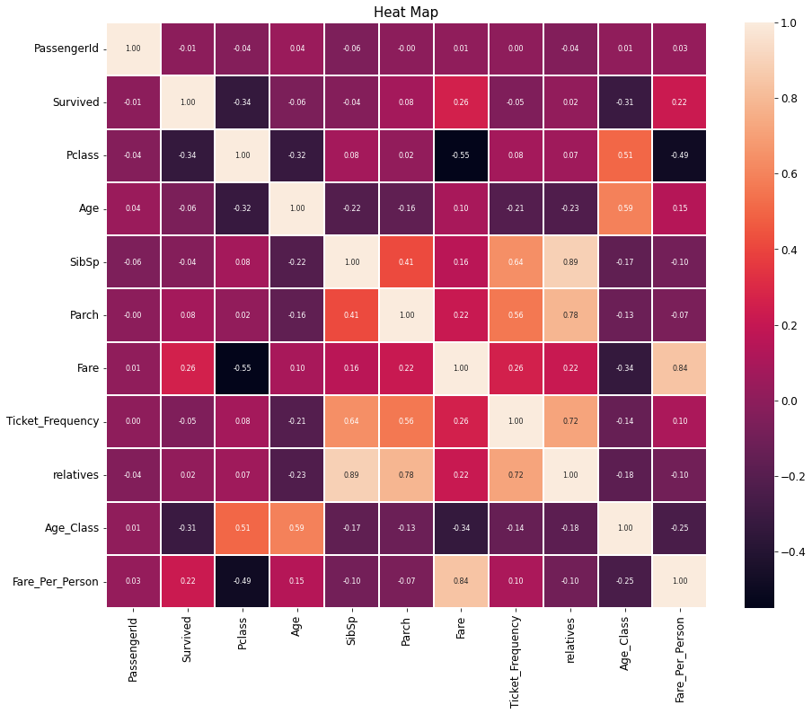

```python
## Check correlations heatmap of varaibales after feature engineering

plt.figure(figsize=(15, 12))
sns.heatmap(df_train.corr(method = 'pearson'), # pearson correlation
            annot = True,
            fmt = '.2f',
            linewidths = 0.1,
            linecolor= 'white',
           annot_kws={'size':8})
plt.title('Heat Map', fontsize = 15)
plt.show()
```

Survived vs Pclass: There is a moderate negative correlation (-0.34) between survival and passenger class (Pclass). This indicates that passengers in higher classes (lower Pclass values) had a higher chance of survival.

ENCODING

```python
## dorp the target variable from the train dataset
df_train.drop(['Survived'],axis =1, inplace =True)
#df_test.drop('PassengerId',axis =1, inplace =True) # no significants
```

Drop the target varable 'Survived' from the train dataset.

```python
## make the class varable to object type.
mydata = [df_train, df_test]

for group in mydata:
    group[['Parch','SibSp','Pclass', 'relatives', 'Ticket_Frequency']] = group[['Parch','SibSp','Pclass', 'relatives', 'Ticket_Frequency']].astype(object)
```

This is to ensure class type varable changed to object datatype

```python
## Inspect object variables in train dataset
objects_names = df_train.select_dtypes(include=['object']).columns # check object data type columns
objects_names
```

```
Index(['Pclass', 'Sex', 'SibSp', 'Parch', 'Embarked', 'Ticket_Frequency', 'relatives', 'alone', 'Location', 'Title'], dtype='object')
```

```python
## Inspect object variables in test dataset
objects_names = df_test.select_dtypes(include=['object']).columns # check object data type columns
objects_names
```

```
Index(['Pclass', 'Sex', 'SibSp', 'Parch', 'Embarked', 'Ticket_Frequency', 'relatives', 'alone', 'Location', 'Title'], dtype='object')
```

```python
## One hot encoding of object data type of train dataset
df_train_ss = pd.DataFrame(data = df_train)
encoded_train = list(df_train.select_dtypes(include=['object']).columns)

for i in encoded_train:
    encoded = pd.get_dummies(df_train_ss[i], prefix=i,
                             drop_first=True) # function to one-hot encoding
    df_train_ss = pd.concat([df_train_ss, encoded], axis=1)# concatenates the df_train_ss DataFrame with the encoded_cols
    df_train_ss.drop(i, axis=1, inplace=True) # drop the original columns
```

```python
df_train_ss # view train dataset after encoding
```

|  | PassengerId | Age | Fare | Age_Class | Fare_Per_Person | Pclass_2 | ... | Location_G | Location_U | Title_Miss | Title_Mr | Title_Mrs | Title_Other |
| --- | --- | --- | --- | --- | --- | --- | --- | --- | --- | --- | --- | --- | --- |
| 0 | 1 | 22 | 7 | 66 | 3 | 0 | ... | 0 | 0 | 0 | 1 | 0 | 0 |
| 1 | 2 | 38 | 71 | 38 | 35 | 0 | ... | 0 | 0 | 0 | 0 | 1 | 0 |
| 2 | 3 | 26 | 7 | 78 | 7 | 0 | ... | 0 | 0 | 1 | 0 | 0 | 0 |
| 3 | 4 | 35 | 53 | 35 | 26 | 0 | ... | 0 | 0 | 0 | 0 | 1 | 0 |
| 4 | 5 | 35 | 8 | 105 | 8 | 0 | ... | 0 | 0 | 0 | 1 | 0 | 0 |
| ... | ... | ... | ... | ... | ... | ... | ... | ... | ... | ... | ... | ... | ... |
| 886 | 887 | 27 | 13 | 54 | 13 | 1 | ... | 0 | 0 | 0 | 0 | 0 | 1 |
| 887 | 888 | 19 | 30 | 19 | 30 | 0 | ... | 0 | 0 | 1 | 0 | 0 | 0 |
| 888 | 889 | 18 | 23 | 54 | 5 | 0 | ... | 0 | 0 | 1 | 0 | 0 | 0 |
| 889 | 890 | 26 | 30 | 26 | 30 | 0 | ... | 0 | 0 | 0 | 1 | 0 | 0 |
| 890 | 891 | 32 | 7 | 96 | 7 | 0 | ... | 0 | 0 | 0 | 1 | 0 | 0 |

891 rows × 46 columns

```python
df_train_ss.columns
```

```
Index(['PassengerId', 'Age', 'Fare', 'Age_Class', 'Fare_Per_Person', 'Pclass_2', 'Pclass_3', 'Sex_male', 'SibSp_1', 'SibSp_2', 'SibSp_3', 'SibSp_4', 'SibSp_5', 'SibSp_8', 'Parch_1', 'Parch_2', 'Parch_3', 'Parch_4', 'Parch_5', 'Parch_6', 'Embarked_Q', 'Embarked_S', 'Ticket_Frequency_1', 'Ticket_Frequ…
```

```python
#drop location U
df_train_ss.drop('Location_U', axis =1, inplace = True)
```

```python
#drop Ticket_frequecny_1
df_train_ss.drop('Ticket_Frequency_1', axis =1, inplace = True)
```

Since the Location_U only exists just 1 datapoint in the train dataset, it is dropped.

```python
## One hot encoding of object data type of test dataset
df_test_ss = pd.DataFrame(data = df_test)
encoded_test = list(df_test.select_dtypes(include=['object']).columns)

for i in encoded_test:
    if i in df_test_ss.columns:
        encoded_test = pd.get_dummies(df_test_ss[i], prefix=i,
                                      drop_first=True) # function to one-hot encoding
        df_test_ss = pd.concat([df_test_ss, encoded_test], axis=1) # concatenates the df_train_ss DataFrame with the encoded_cols
        df_test_ss.drop(i, axis=1, inplace=True) # drop the original columns
```

```python
df_test_ss.columns
```

```
Index(['PassengerId', 'Age', 'Fare', 'Age_Class', 'Fare_Per_Person', 'Pclass_2', 'Pclass_3', 'Sex_male', 'SibSp_1', 'SibSp_2', 'SibSp_3', 'SibSp_4', 'SibSp_5', 'SibSp_8', 'Parch_1', 'Parch_2', 'Parch_3', 'Parch_4', 'Parch_5', 'Parch_6', 'Parch_9', 'Embarked_Q', 'Embarked_S', 'Ticket_Frequency_1', 'T…
```

```python
#drop location U
#df_test_ss.drop('Parch_9', axis =1, inplace = True)
```

```python
## Assign the encoded data to df_train
df_train = df_train_ss
## Assign the encoded data to df_test
df_test = df_test_ss
```

```python
df_train
```

|  | PassengerId | Age | Fare | Age_Class | Fare_Per_Person | Pclass_2 | ... | Location_F | Location_G | Title_Miss | Title_Mr | Title_Mrs | Title_Other |
| --- | --- | --- | --- | --- | --- | --- | --- | --- | --- | --- | --- | --- | --- |
| 0 | 1 | 22 | 7 | 66 | 3 | 0 | ... | 0 | 0 | 0 | 1 | 0 | 0 |
| 1 | 2 | 38 | 71 | 38 | 35 | 0 | ... | 0 | 0 | 0 | 0 | 1 | 0 |
| 2 | 3 | 26 | 7 | 78 | 7 | 0 | ... | 0 | 0 | 1 | 0 | 0 | 0 |
| 3 | 4 | 35 | 53 | 35 | 26 | 0 | ... | 0 | 0 | 0 | 0 | 1 | 0 |
| 4 | 5 | 35 | 8 | 105 | 8 | 0 | ... | 0 | 0 | 0 | 1 | 0 | 0 |
| ... | ... | ... | ... | ... | ... | ... | ... | ... | ... | ... | ... | ... | ... |
| 886 | 887 | 27 | 13 | 54 | 13 | 1 | ... | 0 | 0 | 0 | 0 | 0 | 1 |
| 887 | 888 | 19 | 30 | 19 | 30 | 0 | ... | 0 | 0 | 1 | 0 | 0 | 0 |
| 888 | 889 | 18 | 23 | 54 | 5 | 0 | ... | 0 | 0 | 1 | 0 | 0 | 0 |
| 889 | 890 | 26 | 30 | 26 | 30 | 0 | ... | 0 | 0 | 0 | 1 | 0 | 0 |
| 890 | 891 | 32 | 7 | 96 | 7 | 0 | ... | 0 | 0 | 0 | 1 | 0 | 0 |

891 rows × 44 columns

```python
df_test
```

|  | PassengerId | Age | Fare | Age_Class | Fare_Per_Person | Pclass_2 | ... | Location_F | Location_G | Title_Miss | Title_Mr | Title_Mrs | Title_Other |
| --- | --- | --- | --- | --- | --- | --- | --- | --- | --- | --- | --- | --- | --- |
| 0 | 892 | 34 | 7 | 102 | 7 | 0 | ... | 0 | 0 | 0 | 1 | 0 | 0 |
| 1 | 893 | 47 | 7 | 141 | 3 | 0 | ... | 0 | 0 | 0 | 0 | 1 | 0 |
| 2 | 894 | 62 | 9 | 124 | 9 | 1 | ... | 0 | 0 | 0 | 1 | 0 | 0 |
| 3 | 895 | 27 | 8 | 81 | 8 | 0 | ... | 0 | 0 | 0 | 1 | 0 | 0 |
| 4 | 896 | 22 | 12 | 66 | 4 | 0 | ... | 0 | 0 | 0 | 0 | 1 | 0 |
| ... | ... | ... | ... | ... | ... | ... | ... | ... | ... | ... | ... | ... | ... |
| 413 | 1305 | 38 | 8 | 114 | 8 | 0 | ... | 0 | 0 | 0 | 1 | 0 | 0 |
| 414 | 1306 | 39 | 108 | 39 | 108 | 0 | ... | 0 | 0 | 0 | 0 | 0 | 1 |
| 415 | 1307 | 38 | 7 | 114 | 7 | 0 | ... | 0 | 0 | 0 | 1 | 0 | 0 |
| 416 | 1308 | 24 | 8 | 72 | 8 | 0 | ... | 0 | 0 | 0 | 1 | 0 | 0 |
| 417 | 1309 | 16 | 22 | 48 | 7 | 0 | ... | 0 | 0 | 0 | 0 | 0 | 0 |

418 rows × 46 columns

After encoding both datasets, new columns have been added to represent the encoded features. These new columns reflect the transformed and encoded values of the original features. Additionally, the first column has been dropped from the encoded datasets.

CORRELATION HEATMAP OF TRAIN DATA FEATURES

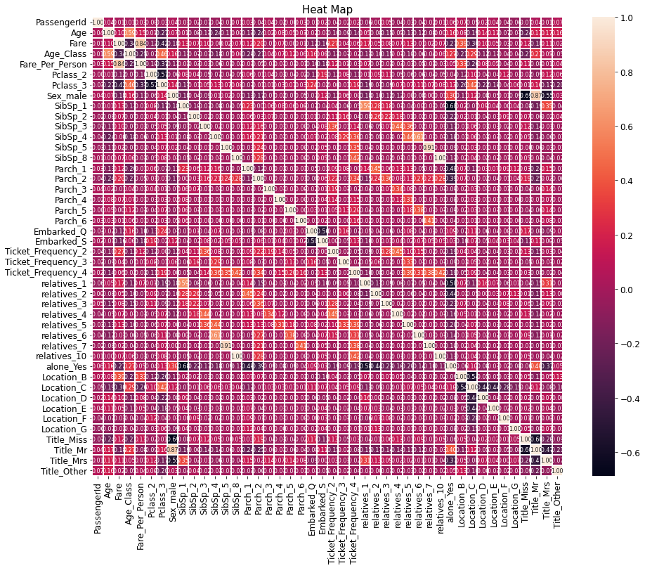

```python
## Correlation check after dropping features in train dataset

plt.figure(figsize=(15, 12))
sns.heatmap(df_train.corr(method = 'pearson'),
            annot = True,
            fmt = '.2f',
            linewidths = 0.1,
            linecolor= 'white',
           annot_kws={'size':8})
plt.title('Heat Map', fontsize = 15)
plt.show()
```

CORRELATION HEATMAP OF TEST DATA FEATURES

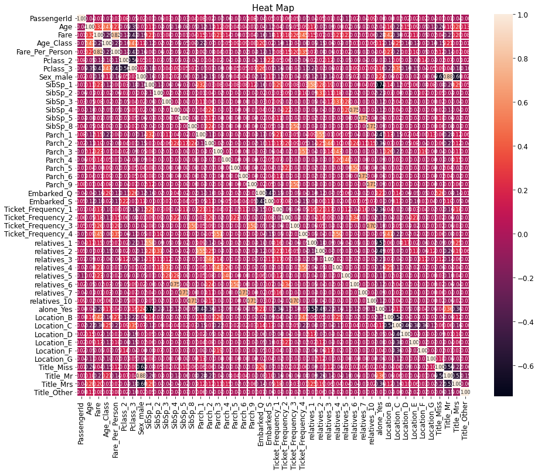

```python
## Correlation check after dropping features in test dataset

plt.figure(figsize=(15, 12))
sns.heatmap(df_test.corr(method = 'pearson'),
            annot = True,
            fmt = '.2f',
            linewidths = 0.1,
            linecolor= 'white',
           annot_kws={'size':8})
plt.title('Heat Map', fontsize = 15)
plt.show()
```

```python
#Drop highly correlated features

#df_train.drop(['Sex_male','alone_Yes', 'Fare'], axis =1, inplace = True)

#df_test = df_test[df_train.columns]
```

Applied a correlation threshold of >= 0.6 and identified several features with high correlations. For example, the feature "Sex_male" showed correlations with "Title_Mrs," "Title_Mr," and "Title_Miss." Additionally, "Fare" was correlated with "Fare_Per_Person," and "alone_Yes" was correlated with "Parch" and "SibSp."

During the feature engineering process, certain parent features were initially removed due to redundancy. However, it was observed that the newly created features, along with their parent features, still held significant predictive power for the "Survived" class. As a result, these parent features were reintroduced into the feature set. For instance, features like "Parch" and "SibSp" were found to be valuable in predicting the target variable.

SELECT FEATURES FOR MODEL BUILDING

```python
## Checking for importants of Features

## import libraries
from sklearn.feature_selection import SelectKBest
from sklearn.feature_selection import mutual_info_classif

## Assigning X as predictors and y as target as usual
X = df_train # Predcictors
y = target # Target

selector = SelectKBest(score_func=mutual_info_classif, k='all') # f_classif to get feature scores
selector.fit(X, y) # fitting with selector

f_scores = selector.scores_ # get feature scores
f_names = X.columns # get feature names

f_scores_df = pd.DataFrame({'Feature': f_names, 'Score': f_scores})# dataframe to store feature name and score
f_scores_df = f_scores_df.sort_values(by='Score', ascending=False) # sort the feature score

#f_scores_df # display the feature with scores
```

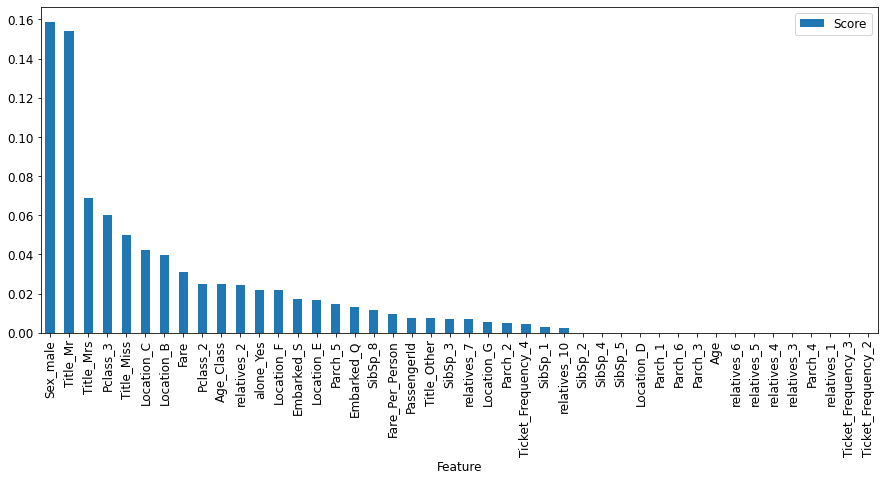

```python
## Review the feature importance

labels = list(set(f_scores_df['Feature']))
fig = plt.figure(figsize=(15, 6))
ax = fig.add_subplot(111)
f_scores_df.plot.bar(x='Feature', y='Score', ax=ax)

plt.show()
```

The bar chart above displays the important features identified in predicting the target variable 'Survived' for the classification models. It provides a visual representation of the relative importance of each feature in predicting the target variable. Based on this information, we can proceed to select the appropriate features that contribute significantly to the classification task. These selected features can then be used as inputs for building and training the classification models, potentially improving their performance and interpretability.

Trying another Lasso feature selection method

LASSO FEATURE SELECTION METHOD

```python
from sklearn.linear_model import Lasso
from sklearn.model_selection import GridSearchCV

lasso = Lasso()

# Define the alpha values to be searched
#param_grid = {'alpha': [0.01, 0.1, 1.0, 10.0]}
param_grid = {'alpha': np.linspace(0, 1, 1000)}

# Perform grid search with cross-validation
#grid_search = GridSearchCV(lasso, param_grid, cv=5)
#grid_search.fit(X, y)

#best_alpha = grid_search.best_params_['alpha']
#print("Best alpha:", best_alpha)
```

```python
## feature selection
#import libraries

from sklearn.linear_model import Lasso
from sklearn.feature_selection import SelectFromModel

lasso = Lasso(alpha=0.003)  # set the alpha value as per your requirement
lasso.fit(X, y)

my_feature = SelectFromModel(lasso, prefit=True) # lasso feature selection
X_selected = my_feature.transform(X) # selected features based on lasso co efficients

feature_id = my_feature.get_support(indices=True) # get the selected feature names
selected_f = X.columns[feature_id]
print("Selected Features:")
print(selected_f)
```

```
Selected Features:
Index(['Age', 'Fare', 'Age_Class', 'Fare_Per_Person', 'Pclass_3', 'Sex_male', 'SibSp_1', 'SibSp_4', 'Parch_2', 'Embarked_S', 'Ticket_Frequency_3', 'Ticket_Frequency_4', 'relatives_2', 'relatives_4', 'relatives_5', 'alone_Yes', 'Location_C', 'Location_E', 'Title_Mr', 'Title_Mrs', 'Title_Other'], dtyp…
```

```python
## Extract the subset of colums and store into new data frame
df_train = df_train[selected_f] # assign itself
#X_test = X_test[X_selected.columns] # assign itself
df_test = df_test[selected_f] # map the list of column names of train data
```

```python
df_train
```

|  | Age | Fare | Age_Class | Fare_Per_Person | Pclass_3 | Sex_male | ... | alone_Yes | Location_C | Location_E | Title_Mr | Title_Mrs | Title_Other |
| --- | --- | --- | --- | --- | --- | --- | --- | --- | --- | --- | --- | --- | --- |
| 0 | 22 | 7 | 66 | 3 | 1 | 1 | ... | 0 | 1 | 0 | 1 | 0 | 0 |
| 1 | 38 | 71 | 38 | 35 | 0 | 0 | ... | 0 | 1 | 0 | 0 | 1 | 0 |
| 2 | 26 | 7 | 78 | 7 | 1 | 0 | ... | 1 | 1 | 0 | 0 | 0 | 0 |
| 3 | 35 | 53 | 35 | 26 | 0 | 0 | ... | 0 | 1 | 0 | 0 | 1 | 0 |
| 4 | 35 | 8 | 105 | 8 | 1 | 1 | ... | 1 | 1 | 0 | 1 | 0 | 0 |
| ... | ... | ... | ... | ... | ... | ... | ... | ... | ... | ... | ... | ... | ... |
| 886 | 27 | 13 | 54 | 13 | 0 | 1 | ... | 1 | 1 | 0 | 0 | 0 | 1 |
| 887 | 19 | 30 | 19 | 30 | 0 | 0 | ... | 1 | 0 | 0 | 0 | 0 | 0 |
| 888 | 18 | 23 | 54 | 5 | 1 | 0 | ... | 0 | 1 | 0 | 0 | 0 | 0 |
| 889 | 26 | 30 | 26 | 30 | 0 | 1 | ... | 1 | 1 | 0 | 1 | 0 | 0 |
| 890 | 32 | 7 | 96 | 7 | 1 | 1 | ... | 1 | 1 | 0 | 1 | 0 | 0 |

891 rows × 21 columns

View the selected feature inmportance in terms of a classifier " Random Forest"

```python
# Check feature importance with classifier
rf = RandomForestClassifier()
rf.fit(df_train,y)

importances = pd.DataFrame({'feature':df_train.columns,'importance':np.round(rf.feature_importances_,3)})
importances = importances.sort_values('importance',ascending=False).set_index('feature')
importances.head()
```

| feature | importance |
| --- | --- |
| Age_Class | 0.169 |
| Title_Mr | 0.141 |
| Age | 0.138 |
| Sex_male | 0.131 |
| Fare | 0.098 |

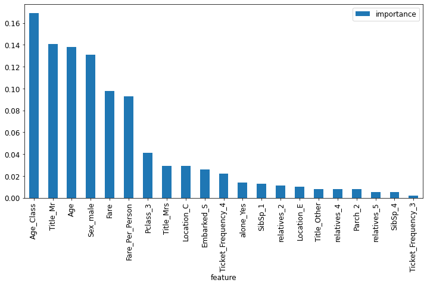

```python
## Importances.plot.bar()
fig = plt.figure(figsize=(12, 6))
ax = fig.add_subplot(111)

importances.plot.bar(ax=ax)

plt.show()
```

```python
## Split the training data into 80/20 for training and testing. Also ensured stratfication

X_train,X_test, y_train, y_test = train_test_split(df_train,target , test_size=0.20, stratify = target,random_state=42)
```

```python
print(X_train.shape)
print(X_test.shape)
print(y_train.shape)
print(y_test.shape)
```

```
(712, 21)
(179, 21)
(712,)
(179,)
```

The training dataset df_train is being split into two subsets: a training set and a testing set. The split is performed in a ratio of approximately 80% for training and 20% for testing.

Stratification is used in classification tasks to ensure that the distribution of classes in the training and testing datasets remains representative of the original dataset. It is important to maintain the proportion of different classes in both the training and testing sets, especially when dealing with imbalanced datasets where the classes are not evenly distributed.

STANDARD SCALING

```python
## Standardizing the feature to mean 0 and std 1
#from sklearn.preprocessing import StandardScaler

scaler = StandardScaler()
X_train = scaler.fit_transform(X_train)
X_test = scaler.fit_transform(X_test)
df_test = scaler.fit_transform(df_test)
```

```python
X_train # review standardized X_train data
```

```
array([[-0.33397911,  0.51234457,  0.29880658, ...,  0.85332019,
        -0.42054667, -0.1743294 ],
       [-1.00214587, -0.65378186, -0.94129947, ...,  0.85332019,
        -0.42054667, -0.1743294 ],
       [ 0.77963216,  3.9482528 , -0.71058206, ...,  0.85332019,
        -0.42054667, -0.1743294 ],
       ...,
       [ 1.37355817,  0.05422348,  2.2887442 , ..., -1.17189306,
         2.37785736, -0.1743294 ],
       [ 1.29931742,  0.13751822, -0.50870433, ...,  0.85332019,
        -0.42054667, -0.1743294 ],
       [ 0.48266916, -0.11236601, -0.82594077, ...,  0.85332019,
        -0.42054667, -0.1743294 ]])
```

```python
X_test# review standardized X_test data
```

```
array([[-0.3530205 , -0.16746842,  0.31980498, ...,  0.83950099,
        -0.33436693, -0.18623126],
       [ 1.12685466, -0.31098415,  2.27913495, ...,  0.83950099,
        -0.33436693, -0.18623126],
       [-0.50100801, -0.47243934,  0.12387198, ...,  0.83950099,
        -0.33436693, -0.18623126],
       ...,
       [-0.05704547, -0.41862094, -0.20268302, ...,  0.83950099,
        -0.33436693, -0.18623126],
       [-0.42701426, -0.36480254, -0.52923801, ..., -1.19118383,
         2.99072641, -0.18623126],
       [ 0.16493581, -0.13158949, -0.00675002, ...,  0.83950099,
        -0.33436693, -0.18623126]])
```

```python
df_test # review standardized test data
```

```
array([[ 0.28515388, -0.50429243,  1.26737504, ...,  0.86120071,
        -0.45617155, -0.13050529],
       [ 1.27211325, -0.50429243,  2.55400773, ..., -1.1611695 ,
         2.19215774, -0.13050529],
       [ 2.41091251, -0.46844307,  1.99316784, ...,  0.86120071,
        -0.45617155, -0.13050529],
       ...,
       [ 0.58883369, -0.50429243,  1.66326202, ...,  0.86120071,
        -0.45617155, -0.13050529],
       [-0.47404563, -0.48636775,  0.27765758, ...,  0.86120071,
        -0.45617155, -0.13050529],
       [-1.08140524, -0.23542223, -0.51411639, ..., -1.1611695 ,
        -0.45617155, -0.13050529]])
```

```python
# Print the mean and standard deviation

print("Train Mean:\n", np.mean(X_train))
print("\nTrain Standard Deviation:\n", np.std(X_train))
print("\nTest Mean:\n", np.mean(X_test))
print("\nTest Standard Deviation:\n", np.std(X_test))
```

```
Train Mean:
 2.1622321078842e-17

Train Standard Deviation:
 1.0

Test Mean:
 -3.544207580607044e-18

Test Standard Deviation:
 1.0
```

```python
print("\ndf_test Mean:\n", np.mean(df_test))
print("\ndf_test Standard Deviation:\n", np.std(df_test))
```

```
df_test Mean:
 8.904044307770679e-18

df_test Standard Deviation:
 1.0
```

Both datasets have undergone a standardization process, as demonstrated above. This transformation has resulted in both datasets being scaled to the same standard scale, where the standard deviation is 1. Standardization ensures that the values of the features in the datasets are adjusted to a common scale, allowing for fairer comparisons and analysis.

```python
## Check the shape of the split
X_train.shape, y_train.shape,X_test.shape,y_test.shape
```

```
((712, 21), (712,), (179, 21), (179,))
```

# BUILDING CLASSIFICATION MODELS

```python
## Load multipple classification models
## Loop over the models and review results

models = []
models.append(('LR', LogisticRegression(solver='liblinear', multi_class='ovr')))
models.append(('LDA', LinearDiscriminantAnalysis()))
models.append(('KNN', KNeighborsClassifier()))
models.append(('CART', DecisionTreeClassifier()))
models.append(('NB', GaussianNB()))
models.append(('SVM', SVC(gamma='auto')))
models.append(('RF',RandomForestClassifier(n_jobs=-1)))
models.append(('CB',CatBoostClassifier(verbose = False)))


## Evaluate each model in turn
results = [] # print the accuracy score
names = []   # print the model name

for name, model in models: # loop over the models to get the accuracy score of both train and test
    fit = model.fit(X_train, y_train)
    train_predict = model.predict(X_train)
    test_predict = model.predict(X_test)
    accuracy_train = accuracy_score(y_train,train_predict)
    accuracy_test = accuracy_score(y_test,test_predict)

    results.append({
        'Model': name,
        'Score': [accuracy_train, accuracy_test]
    })

result_df = pd.DataFrame(results) # data frame of the results
result_df['Score'] = result_df['Score'].apply(lambda x: ['{:.2f}'.format(score) for score in x]) # round to 2 decimals
result_df = result_df.set_index('Score') # set index as score
result_df = result_df.sort_values(by='Score', ascending=False)

result_df
```

| Score | Model |
| --- | --- |
| [0.98, 0.79] | RF |
| [0.98, 0.77] | CART |
| [0.91, 0.80] | CB |
| [0.86, 0.81] | KNN |
| [0.86, 0.81] | SVM |
| [0.84, 0.84] | LR |
| [0.83, 0.83] | LDA |
| [0.45, 0.61] | NB |

K-FOLD CROSS VALIDATION

```python
## K-fold cross validation on training set

for name, model in models:
    kfold = StratifiedKFold(n_splits=10, random_state=1, shuffle=True)
    cv_results = cross_val_score(model, X_train, y_train, cv=kfold, scoring='accuracy')
    results.append(cv_results)
    names.append(name)


    print(name,'{:,.2f}%'.format(cv_results.mean()*100),'({:,.3f})'.format(cv_results.std())) # print the mean and standard deviation
    print()
```

```
LR 83.17% (0.051)

LDA 82.46% (0.044)

KNN 80.49% (0.060)

CART 79.36% (0.049)

NB 45.09% (0.050)

SVM 83.58% (0.043)

RF 81.62% (0.046)

CB 84.28% (0.045)
```

Given the relatively stable accuracy and the ease of use of the Random Forest model, I will focus on further improving its performance in the following section.

About Random Forest classifier

Random Forest is a supervised learning algorithm that builds a "forest" of decision trees through a randomization process. The ensemble of decision trees is typically trained using the "bagging" method. In simple terms, Random Forest constructs multiple decision trees and combines their predictions to achieve more accurate and stable results.

One significant advantage of Random Forest is its versatility in handling both classification and regression problems, which are prevalent in many machine learning systems. It inherits the hyperparameters of decision-tree classifiers and bagging classifiers, allowing control over the ensemble itself.

The algorithm introduces additional randomness during tree construction. Instead of searching for the best feature to split a node, Random Forest randomly selects a subset of features and finds the best feature among them. This process introduces diversity, leading to improved model performance. When growing a tree in Random Forest, only a random subset of features is considered for each node's splitting. To further increase randomness, random thresholds can be applied to each feature, rather than searching for the best possible thresholds as done in traditional decision trees.

Another great quality of random forest is that they make it very easy to measure the relative importance of each feature. Sklearn measure a features importance by looking at how much the treee nodes, that use that feature, reduce impurity on average (across all trees in the forest). It computes this score automatically for each feature after training and scales the results so that the sum of all importances is equal to 1.

```python
## Retry Random Forest algoritam

rf= RandomForestClassifier(n_estimators=100, oob_score = True)
rf.fit(X_train, y_train)
y_prediction = rf.predict(X_test)

acc_rf = round(rf.score(X_train, y_train) * 100, 2)

print(round(acc_rf,2,), "%")
#print("oob score:", round(rf.oob_score_, 4)*100, "%")
print("oob score:", round(rf.oob_score_ * 100, 2),'%')
```

```
97.61 %
oob score: 81.04 %
```

The out-of-bag (oob) score is a metric used to evaluate the performance of a Random Forest model. In Random Forest, each decision tree is trained on a bootstrap sample of the original dataset, which means some samples are left out or "out-of-bag" in each iteration.

HYPER PARAMETER TUNING

```python
## Hyperparameter Tuning with Randaom forest

param_grid = {
    "criterion": ["gini", "entropy"],
    "min_samples_leaf": [5,6],

    "min_samples_split": [2,3,4],
    "n_estimators":np.linspace(100,500,4,dtype=int),
    "max_depth":[None,5,10]
}

rf = RandomForestClassifier(n_estimators=100, oob_score=True, random_state=42, n_jobs=-1)
clf = GridSearchCV(estimator=rf, param_grid=param_grid, cv=10, verbose=2, n_jobs=-1)

#clf.fit(X_train, y_train)
#print(clf.best_params_)
```

Tuned best parameter combination as shown below.

Fitting 10 folds for each of 144 candidates, totalling 1440 fits {'criterion': 'gini', 'max_depth': 5, 'min_samples_leaf': 6, 'min_samples_split': 2, 'n_estimators': 233}

Fitting 10 folds for each of 144 candidates, totalling 1440 fits {'criterion': 'entropy', 'max_depth': None, 'min_samples_leaf': 5, 'min_samples_split': 2, 'n_estimators': 366}

RETRAINING THE MODEL WITH BEST PARAMETERS

```python
## Retrain in Random Forest algoritam

rf = RandomForestClassifier(criterion = 'entropy',
                            min_samples_leaf = 5,
                            min_samples_split = 2,
                            n_estimators = 366,
                            oob_score = True,
                            random_state = 42,
                            max_depth = None,
                            n_jobs=-1)

rf.fit(X_train, y_train)
y_prediction = rf.predict(X_test)

acc_rf = round(rf.score(X_train, y_train) * 100, 2)

print("Accuracy:", round(acc_rf,2,), "%")
print("oob score:", round(rf.oob_score_ * 100, 2),'%')
```

```
Accuracy: 88.2 %
oob score: 82.3 %
```

```python
## K-fold cross validation on training set

kfold = StratifiedKFold(n_splits=10, random_state=1, shuffle=True)
cv_results = cross_val_score(rf, X_train, y_train, cv=kfold, scoring='accuracy')
results = cv_results.mean() * 100
std_dev = cv_results.std()

print('CV RF: {:,.2f}%'.format(results), '({:,.3f})'.format(std_dev)) # print the mean and standard deviation
```

```
CV RF: 84.00% (0.041)
```

With our refined model in place with an improved obb score with the training score, we can now proceed to evaluate its performance in a more comprehensive manner.

Before, the further analysis, compare with the performance CatBoostClassifier

```python
## Hyper parameter check with cat booster

cb = CatBoostClassifier(iterations=100,
                        learning_rate=0.001,
                        depth=8,
                        l2_leaf_reg = 3,
                        loss_function='Logloss',
                       verbose = False)


param_grid = {
    #'iterations': np.linspace (100,700,2,dtype = int),
      'iterations':(100,200,500,600),
    'learning_rate': [0.3, 0.2, 0.1],
    'depth': [8,10,11]
}

# Perform grid search with cross-validation
#clf = GridSearchCV(estimator=cb, param_grid=param_grid, cv=10, verbose=2, n_jobs=-1)
#clf.fit(X_train, y_train)

# Print the best parameters found
#print(clf.best_params_)
```

Best parameters

Fitting 10 folds for each of 36 candidates, totalling 360 fits {'depth': 8, 'iterations': 100, 'learning_rate': 0.3}

Fitting 10 folds for each of 36 candidates, totalling 360 fits {'depth': 8, 'iterations': 100, 'learning_rate': 0.2}

```python
# catboost
cb = CatBoostClassifier(iterations=100,
                        learning_rate=0.2,
                        depth=8,
                        #l2_leaf_reg = 3,
                        #loss_function='Logloss',
                       verbose = False)


cb.fit(X_train, y_train)
#y_prediction = random_forest.predict(X_test)

train_accuracy = cb.score(X_train, y_train)

#print("oob score:", round(random_forest.oob_score_, 4)*100, "%")
#print("Accuracy:", round(train_accuracy, 4) * 100, "%")
print("Accuracy:", round(train_accuracy * 100, 2),'%')
```

```
Accuracy: 97.19 %
```

In our previous assessments, we relied primarily on accuracy and the out-of-bag (OOB) score, which is essentially a variant of accuracy. However, evaluating a classification model goes beyond these simple metrics, and the process can be more intricate compared to evaluating a regression model.

In the upcoming section, we will delve into the complexities involved in assessing the performance of a classification model and explore alternative evaluation measures that provide a more comprehensive understanding of its effectiveness.

EVALUATION OF MODEL PERFORMANCES

CONFUSION MATRIX

```python
## Evaluating confution metrix
from sklearn.model_selection import cross_val_predict

predictions_cb = cross_val_predict(cb, X_train, y_train, cv=10)
predictions_rf = cross_val_predict(rf, X_train, y_train, cv=10)

print('Confusion Matrix_RandomForest:\n',confusion_matrix(y_train, predictions_rf))
print()
print('Confusion Matrix_CatBoost:\n', confusion_matrix(y_train, predictions_cb))
```

```
Confusion Matrix_RandomForest:
 [[394  45]
 [ 83 190]]

Confusion Matrix_CatBoost:
 [[385  54]
 [ 82 191]]
```

The confusion matrix provides valuable information about the model's performance. However, to gain further insights, we can compute the precision of the classifier.

By computing the classifier's precision, we can obtain additional information regarding the accuracy of the positive predictions.

PRECISION & RECALL

```python
## Compare Precision and Recall of both models
from sklearn.metrics import precision_score, recall_score

precision_rf = precision_score(y_train, predictions_rf)
recall_rf = recall_score(y_train, predictions_rf)

precision_cb = precision_score(y_train, predictions_cb)
recall_cb = recall_score(y_train, predictions_cb)

print("Recall_RandomForest: {:.2%}".format(recall_rf))
print("Precision_RandomForest: {:.2%}".format(precision_rf))
print()
print("Recall_CatBoost: {:.2%}".format(recall_cb))
print("Precision_CatBoost: {:.2%}".format(precision_cb))
```

```
Recall_RandomForest: 69.60%
Precision_RandomForest: 80.85%

Recall_CatBoost: 69.96%
Precision_CatBoost: 77.96%
```

These findings align with the information from the confusion matrix, which highlights the strengths and weaknesses of each model in predicting true positives and true negatives. The precision score emphasizes the accuracy of survival predictions, while the recall score reflects the model's ability to identify the passengers who truly survived.

F- SCORE

```python
## Compare F-score
from sklearn.metrics import f1_score

f1_score_cb =  f1_score(y_train, predictions_cb)
f1_score_rf = f1_score(y_train, predictions_rf)

print("f1_score_RandomForest: {:.2%}".format(precision_rf))
print()
print("f1_score_CatBoost: {:.2%}".format(recall_rf))
```

[output not shown]

The F-score combines precision and recall into a single metric, calculated using the harmonic mean of the two. It is worth noting that the F-score assigns more weight to lower values, emphasizing the importance of having both high precision and recall for a high F-score.

PRECISION & RECALL CURVE

The Random Forest algorithm assigns a classification to each person by calculating a probability using a specific function. If the computed score exceeds a predefined threshold, the person is classified as "survived," while if the score is lower than the threshold, the person is classified as "not survived." Thus, the threshold value plays a crucial role in determining the classification outcome for each individual.

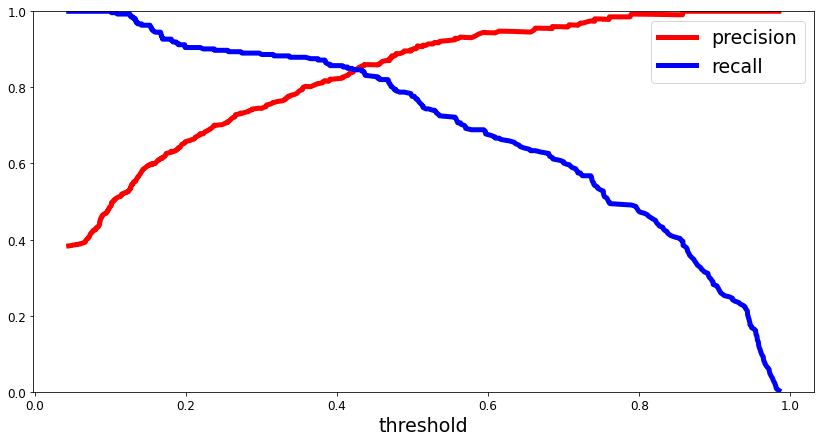

```python
## Precision and recall curve
from sklearn.metrics import precision_recall_curve

## Getting the probabilities of our predictions
y_scores = rf.predict_proba(X_train)
y_scores = y_scores[:,1]

precision_rf, recall_rf, threshold = precision_recall_curve(y_train, y_scores)
def plot_precision_and_recall(precision, recall, threshold):
    plt.plot(threshold, precision_rf[:-1], "r-", label="precision", linewidth=5)
    plt.plot(threshold, recall_rf[:-1], "b", label="recall", linewidth=5)
    plt.xlabel("threshold", fontsize=19)
    plt.legend(loc="upper right", fontsize=19)
    plt.ylim([0, 1])

plt.figure(figsize=(14, 7))
plot_precision_and_recall(precision_rf, recall_rf, threshold)
plt.show()
```

It is evident from the analysis that the recall metric experiences a significant decline once the precision reaches approximately 80%. To address this, it may be preferable to select a precision/recall tradeoff threshold prior to this point, say around 75%.

By examining the precision-recall plots, we can identify the threshold that achieves the desired tradeoff for this machine learning problem. For example, if we aim for a precision of 80%, we can visually inspect the plots and estimate that a threshold of approximately 0.4 would be appropriate. With this threshold value, we can train a model specifically tailored to meet the desired accuracy by emphasizing the precision/recall tradeoff.

Another way is to plot the precision and recall against each other is shown below

[figure not shown]

```python
## Plot precision and recall in another way
def plot_precision_vs_recall(precision_rf, recall_rf):
    plt.plot(recall_rf, precision_rf, "g--", linewidth=2.5)
    plt.ylabel("recall", fontsize=19)
    plt.xlabel("precision", fontsize=19)
    plt.axis([0, 1.5, 0, 1.5])

plt.figure(figsize=(14, 7))
plot_precision_vs_recall(precision_rf, recall_rf)
plt.show()
```

The interpretation is the same as the above chart

THE ROC AUC CURVE

To evaluate and compare binary classifiers, an alternative method is to use the Receiver Operating Characteristic (ROC) curve and the corresponding Area Under the Curve (AUC). Unlike the precision-recall curve, the ROC curve plots the true positive rate (also known as recall) against the false positive rate, which represents the ratio of incorrectly classified negative instances.

Instead of examining the precision-recall tradeoff directly, the ROC curve provides insights into how the true positive rate and false positive rate vary as the classification threshold changes. By analyzing the AUC, which measures the overall performance of the classifier, we can make comparisons between different models and assess their ability to distinguish between positive and negative instances.

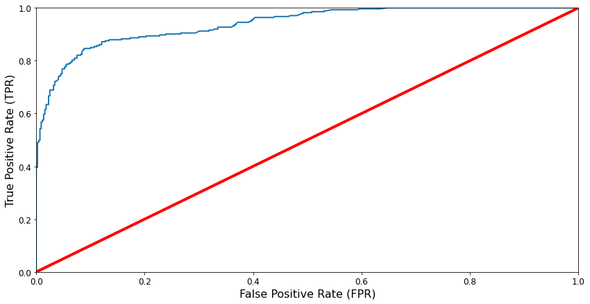

```python
## Plot ROC and AUC curve

from sklearn.metrics import roc_curve

# Compute true positive rate and false positive rate
false_positive_rate, true_positive_rate, thresholds = roc_curve(y_train, y_scores)

# plotting them against each other
def plot_roc_curve(false_positive_rate, true_positive_rate, label=None):
    plt.plot(false_positive_rate, true_positive_rate, linewidth=2, label=label)
    plt.plot([0, 1], [0, 1], 'r', linewidth=4)
    plt.axis([0, 1, 0, 1])
    plt.xlabel('False Positive Rate (FPR)', fontsize=16)
    plt.ylabel('True Positive Rate (TPR)', fontsize=16)

plt.figure(figsize=(14, 7))
plot_roc_curve(false_positive_rate, true_positive_rate)
plt.show()
```

The central red line on the ROC curve represents a random classifier, such as a coin flip, which does not possess any predictive capability. Hence, a desirable classifier should be positioned as far away from this line as possible. In the case of our Random Forest model, it appears to perform well, as it exhibits a considerable deviation from the random classifier line.

However, it's important to note that there is a tradeoff involved. As the true positive rate increases, the classifier tends to generate more false positives. This tradeoff indicates that achieving a higher true positive rate comes at the cost of an increased number of false positives. Therefore, striking the right balance between true positives and false positives is crucial when interpreting the performance of the classifier.

THE ROC AUC SCORE

The ROC AUC Score is a metric associated with the ROC AUC Curve, and it is calculated by measuring the area under the curve (AUC). A perfect classifier that makes all correct predictions would have an ROC AUC Score of 1, while a completely random classifier would have a score of 0.5.

In summary, the ROC AUC Score provides a numerical assessment of the classifier's performance, with higher scores indicating better discrimination between positive and negative instances, while a score of 0.5 suggests a classifier that performs no better than random chance.

KEY FEATURES 21:

'Age', 'Fare', 'Age_Class', 'Fare_Per_Person', 'Pclass_3', 'Sex_male', 'SibSp_1', 'SibSp_4', 'Parch_2', 'Embarked_S', 'Ticket_Frequency_3', 'Ticket_Frequency_4', 'relatives_2', 'relatives_4', 'relatives_5', 'alone_Yes', 'Location_C', 'Location_E', 'Title_Mr', 'Title_Mrs', 'Title_Other'

```python
## Computing ROC AUC Score

from sklearn.metrics import roc_auc_score

r_a_score = roc_auc_score(y_train, y_scores)

print("ROC-AUC-Score_RandomForest: {:.2%}".format( r_a_score))
```

```
ROC-AUC-Score_RandomForest: 93.91%
```

I think the score about 93.91 % is good enough to submit the predictions for the test-set to the Kaggle leaderboard.

```python
## predict the target using the RandomForest
pred = rf.predict(df_test)
```

```python
print(pred) # print the predicted values
```

```
[0 0 0 0 1 0 1 0 1 0 0 0 1 0 1 1 0 0 0 0 0 0 1 0 1 0 1 0 0 0 0 0 0 0 0 0 0
 0 0 0 0 0 0 1 1 0 0 0 1 1 0 0 1 1 0 0 0 0 0 1 0 0 0 1 1 1 1 0 0 1 1 0 0 0
 1 0 0 1 0 1 1 0 0 0 0 0 1 0 0 1 0 0 1 0 0 0 1 0 1 0 1 0 0 0 1 0 0 0 0 0 0
 1 1 1 1 0 0 1 0 1 1 0 1 0 0 0 0 1 0 0 0 0 0 0 0 0 0 0 0 0 0 1 0 0 0 0 0 0
 0 0 1 0 0 1 0 0 1 0 0 1 1 1 1 0 0 0 0 0 1 0 0 0 0 0 0 1 1 0 1 1 0 1 1 0 1
 0 1 0 0 0 0 0 0 0 1 0 1 1 0 1 1 1 1 1 0 0 1 0 1 0 0 0 0 1 0 0 1 0 1 0 1 0
 1 0 1 1 0 1 0 0 0 1 0 0 0 0 0 0 1 1 1 1 1 0 0 0 1 0 1 0 1 0 0 0 0 0 0 0 1
 0 0 0 1 1 0 0 0 0 0 0 0 0 1 0 0 1 0 0 0 0 0 1 1 1 1 0 0 0 0 0 0 1 0 1 0 0
 1 0 0 0 0 0 0 0 1 1 0 1 0 0 0 0 0 1 1 1 0 0 0 0 0 0 0 0 1 0 1 0 0 0 1 0 0
 1 0 0 0 0 0 0 0 0 0 1 0 1 0 1 0 1 1 0 0 0 1 0 1 0 0 0 0 1 1 0 1 0 0 1 1 0
 0 1 0 0 1 1 0 0 0 0 0 0 1 0 0 1 0 0 0 0 0 1 0 0 0 1 0 1 0 0 1 0 1 0 0 0 0
 0 1 1 1 1 0 0 1 0 0 0]
```

```python
## Predict values and store in to the data frame column name Survived

prediction = pd.Series(rf.predict(df_test), name="Survived")
prediction.head(10)
```

```
0    0
1    0
2    0
3    0
4    1
5    0
6    1
7    0
8    1
9    0
Name: Survived, dtype: int64
```

```python
## load the original titanic test data
df_test = pd.read_csv('data/titanic_test.csv')
```

```python
submission = pd.DataFrame({'PassengerId': df_test['PassengerId'], 'Survived': prediction})
submission.to_csv('submission.csv', index=False) # save csv file
```

THE KAGGLE TEST SCORE = 79.43%

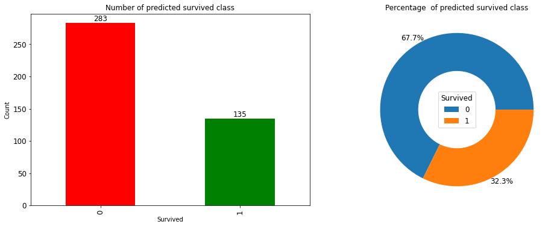

```python
# Bar chart of passengers survived and not survived
plt.figure(figsize=(14, 10))

plt.subplot(221)

bar = submission['Survived'].value_counts()  # Count the number of passengers in each category
colors = ['red', 'green']
bar.plot(kind='bar',color = colors)
plt.xlabel('Survived',fontsize = 10)
plt.ylabel('Count', fontsize = 10)
plt.title('Number of predicted survived class', fontsize = 12)

# Add data labels to the bars
for x, t in enumerate(bar):
    plt.text(x, t, str(t), ha='center', va='bottom')

plt.subplot(222)
pie_data = submission['Survived'].value_counts()  # Extract pie chart data for 'Survived' feature

labels = list(set(submission['Survived']))  # Extract unique labels
labels.sort()

plt.pie(pie_data, autopct='%1.1f%%', pctdistance=1.1)  # Data label format and location spacing
central_circle = plt.Circle((0, 0), 0.5, color='white')  # Center hole sizing and color
fig = plt.gcf()
fig.gca().add_artist(central_circle)
plt.rc('font', size=12)
plt.title("Percentage  of predicted survived class", fontsize=12)
plt.legend(labels, loc="center", title="Survived")  # Legend location and name

plt.tight_layout()
plt.show()
```

Bias and Variances

It can be observed that the model consistently misclassifies the true negative class, resulting in imbalanced error rates in the confusion matrix. Specifically, the number of misclassified true negatives remains around 45. However, there is some variation in the number of true positives, which differs by approximately 5.

On the other hand, when examining the confusion matrix across different runs, small variations are noticed. These inconsistencies can be attributed to variances, indicating that the model's performance fluctuates slightly across different runs.

Overall, the model demonstrates a bias towards misclassifying the true negative class consistently, while also exhibiting some variance in its performance across different runs, leading to slight variations in the confusion matrix.These biases and variances are evident not only when observing the confusion matrix but also in precision and ROC curves.

When assessing the model performance in terms of bias and variance, it can be observed that the model exhibits low bias and demonstrates slight variations between training and test data. This indicates a tradeoff between bias and variance.

By achieving an appropriate balance between bias and variance, a model can generalize well to unseen data while still capturing the underlying patterns in the training data. This balance is vital in building effective and robust machine learning models.

So the total error = Bias ^2 + Varience + Irredicuible error.

This analysis began with data exploration, where I gained an understanding of the dataset, checked for missing data, and identified important features. Visualizations were created using bokeh, seaborn and matplotlib to aid in this process. In the data preprocessing phase, I addressed missing values, transformed features into numeric formats, grouped values into categories, and introduced new features as necessary.

Following preprocessing, I proceeded to train eight different machine learning models. Among them, we selected the random forest model and conducted cross-validation to assess its performance. I delved into the inner workings of the random forest algorithm, examined the assigned importance to various features, and fine-tuned its performance by optimizing hyperparameter values.

Lastly, I examined the confusion matrix of the random forest model and calculated its precision, recall, and F-score, which provided further insights into its overall performance.

The Kaggle submission score for the model is 79.43%. It is crucial to acknowledge that the performance of any model, including Random Forest, relies on several factors such as the dataset, feature quality, and the amount of available training data.

Based on research, it appears that achieving a test score of over 75% for the Titanic dataset is considered satisfactory.

References :

https://towardsdatascience.com/understanding-the-bias-variance-tradeoff-165e6942b229

https://www.linkedin.com/pulse/what-i-learned-analyzing-famous-titanic-dateset-murilo-gustineli/